# BIA 810: FINAL PROJECT#

## Analyzing Competitive Dynamics in the Injectable Anesthesia Market

**By Group 3 – Nikita Vira, Shubh Bhardwaj, Hemanth Pillala, Nikhitha and Sukain**

### Problem Statement:

The project looks at why Midoride is not performing better than the older product, Ketotrom, and how it compares to competitors Fentirate and Profativ. The goal is to find ways to increase Midoride's market share.

### Business Solution:

Boost Midoride’s market share by using Ketotrom’s provider network, focusing on marketing and education, and tailoring strategies for different regions and medical specialties.

### Business Impact:

Help Midoride grow by reversing its decline in market share. This will improve competition, increase revenue, and focus on high-value areas and older patients to drive future growth.

## Loading all claims data files

```python
import pandas as pd
import numpy as np
import matplotlib.pyplot as plt
```

```python
# Read the 5 Medicare claims parts

claims_files = [
    '/Users/nikitavira/Desktop/Stevens/SEMESTER 2/BIA-810 Healthcare Analytics/Finals/Datasets/Medicare_Claims_data_part_1.csv',
    '/Users/nikitavira/Desktop/Stevens/SEMESTER 2/BIA-810 Healthcare Analytics/Finals/Datasets/Medicare_Claims_data_part_2.csv',
    '/Users/nikitavira/Desktop/Stevens/SEMESTER 2/BIA-810 Healthcare Analytics/Finals/Datasets/Medicare_Claims_data_part_3.csv',
    '/Users/nikitavira/Desktop/Stevens/SEMESTER 2/BIA-810 Healthcare Analytics/Finals/Datasets/Medicare_Claims_data_part_4.csv',
    '/Users/nikitavira/Desktop/Stevens/SEMESTER 2/BIA-810 Healthcare Analytics/Finals/Datasets/Medicare_Claims_data_part_5.csv'
]

# Load all files
claims_dfs = [pd.read_csv(file) for file in claims_files]

# Merge them into one dataframe
claims = pd.concat(claims_dfs, ignore_index=True)

# Check first few rows
claims.head()
```

|  | cur_clm_uniq_id | bene_mbi_id | fac_prvdr_npi_num | clm_from_dt | clm_thru_dt | prncpl_dgns_cd | clm_pmt_amt | clm_mdcr_instnl_tot_chrg_amt | clm_line_num | clm_line_hcpcs_cd | clm_line_cvrd_pd_amt | clm_val_sqnc_num_dgns | clm_dgns_cd | clm_val_sqnc_num_prcdr | clm_prcdr_cd | clm_line_alowd_chrg_amt | clm_prvdr_spclty_cd |
| --- | --- | --- | --- | --- | --- | --- | --- | --- | --- | --- | --- | --- | --- | --- | --- | --- | --- |
| 0 | 1272380 | 10791 | 1.316539e+09 | 11/8/2016 | 11/7/2016 | S81811D | 154.73 | 11182.21567 | 11.0 | G8996 | -0.04 | 12.0 | Z951 | NaN | NaN | NaN | NaN |
| 1 | 631196 | 10107 | 1.033202e+09 | 7/21/2016 | 7/12/2016 | S0083XA | NaN | NaN | 1.0 | 76700 | 2.57 | NaN | I10 | NaN | NaN | 8.86 | 69 |
| 2 | 1548564 | 10412 | 1.880497e+09 | 7/14/2018 | 5/20/2018 | R918 | NaN | NaN | 1.0 | C1751 | 53.81 | NaN | I10 | NaN | NaN | 86.40 | 30 |
| 3 | 1427731 | 10934 | 1.655569e+09 | 6/19/2016 | 7/15/2016 | I2119 | 705.89 | 20750.00517 | 17.0 | 85378 | -5.91 | 7.0 | M25552 | NaN | NaN | NaN | NaN |
| 4 | 428779 | 965 | 1.644309e+09 | 3/21/2017 | 8/10/2018 | C4490 | 2884.15 | 18437.66432 | 5.0 | 80061 | 2.62 | 6.0 | Z9049 | NaN | NaN | NaN | NaN |

## Merging all the data together

```python
import pandas as pd

# Step 1: Define base path
base_path = '/Users/nikitavira/Desktop/Stevens/SEMESTER 2/BIA-810 Healthcare Analytics/Finals/Datasets/'

# Step 2: Read all 5 Medicare Claims parts
med_clm_data_1 = pd.read_csv(base_path + 'Medicare_Claims_data_part_1.csv')
med_clm_data_2 = pd.read_csv(base_path + 'Medicare_Claims_data_part_2.csv')
med_clm_data_3 = pd.read_csv(base_path + 'Medicare_Claims_data_part_3.csv')
med_clm_data_4 = pd.read_csv(base_path + 'Medicare_Claims_data_part_4.csv')
med_clm_data_5 = pd.read_csv(base_path + 'Medicare_Claims_data_part_5.csv')

# Step 3: Concatenate them into one dataframe
merged_df = pd.concat(
    [med_clm_data_1, med_clm_data_2, med_clm_data_3, med_clm_data_4, med_clm_data_5],
    ignore_index=True
)

# Step 4: Sort by Claim ID
merged_df = merged_df.sort_values(by=['cur_clm_uniq_id'])

# Step 5: Reset index
merged_df = merged_df.reset_index(drop=True)

# Step 6: Print or inspect
print(merged_df.head())  # Safer to print only first few rows
```

```
   cur_clm_uniq_id  bene_mbi_id  fac_prvdr_npi_num clm_from_dt clm_thru_dt  \
0           100020        10449       7.829223e+09   9/26/2016   12/5/2016
1           100020        10977       7.360579e+09  12/13/2017   6/12/2017
2           100020         1109       1.587946e+09   5/19/2017   7/27/2017
3           100020        10882       1.414857e+09    4/3/2017   6/29/2017
4           100020          963       1.414857e+09   11/3/2018  10/22/2018

  prncpl_dgns_cd  clm_pmt_amt  clm_mdcr_instnl_tot_chrg_amt  clm_line_num  \
0          Z0289          NaN                           NaN           4.0
1           R262          NaN                           NaN           1.0
2           F209      1580.53                   18398.95983          23.0
3          K5000          NaN                           NaN           1.0
4           E785          NaN                           NaN           1.0

  clm_line_hcpcs_cd  clm_line_cvrd_pd_amt  clm_val_sqnc_num_dgns clm_dgns_cd  \
```

[output cut: 19 more lines]

## Filtering the required product codes

```python
conditions = (
    (merged_df['clm_line_hcpcs_cd'] == "J1885") |
    (merged_df['clm_line_hcpcs_cd'] == "J3010") |
    (merged_df['clm_line_hcpcs_cd'] == "J2250") |
    (merged_df['clm_line_hcpcs_cd'] == "J2704")
)

filtered_df = merged_df[conditions]

filtered_df.head()
```

|  | cur_clm_uniq_id | bene_mbi_id | fac_prvdr_npi_num | clm_from_dt | clm_thru_dt | prncpl_dgns_cd | clm_pmt_amt | clm_mdcr_instnl_tot_chrg_amt | clm_line_num | clm_line_hcpcs_cd | clm_line_cvrd_pd_amt | clm_val_sqnc_num_dgns | clm_dgns_cd | clm_val_sqnc_num_prcdr | clm_prcdr_cd | clm_line_alowd_chrg_amt | clm_prvdr_spclty_cd |
| --- | --- | --- | --- | --- | --- | --- | --- | --- | --- | --- | --- | --- | --- | --- | --- | --- | --- |
| 34 | 100020 | 10364 | 1.304896e+09 | 12/27/2016 | 12/10/2016 | Z5181 | NaN | NaN | 3.0 | J3010 | 66.14 | NaN | I10 | NaN | NaN | 93.51 | 34 |
| 302 | 100020 | 12749 | 3.156424e+09 | 11/7/2016 | 1/25/2017 | Z79899 | 73.75 | 718.425135 | 3.0 | J1885 | NaN | 4.0 | I10 | NaN | NaN | NaN | NaN |
| 309 | 100020 | 10055 | 1.866101e+09 | 10/19/2017 | 1/1/2018 | H9313 | NaN | NaN | 1.0 | J1885 | 1.23 | NaN | I10 | NaN | NaN | 9.80 | 69 |
| 319 | 100020 | 12564 | 7.009227e+09 | 11/17/2016 | 9/22/2016 | E041 | 111.07 | 558.601045 | NaN | J1885 | 6.59 | 1.0 | M79602 | NaN | NaN | NaN | NaN |
| 353 | 100020 | 10181 | 9.545956e+09 | 2/23/2017 | 1/3/2017 | I10 | NaN | NaN | 4.0 | J1885 | 1.40 | NaN | I10 | NaN | NaN | 11.81 | 8 |

```python
unique_claim_ids = filtered_df['cur_clm_uniq_id'].unique()

final_df = merged_df[merged_df['cur_clm_uniq_id'].isin(unique_claim_ids)]
print(final_df)
```

```
        cur_clm_uniq_id  bene_mbi_id  fac_prvdr_npi_num clm_from_dt  \
0                100020        10449       7.829223e+09   9/26/2016
1                100020        10977       7.360579e+09  12/13/2017
2                100020         1109       1.587946e+09   5/19/2017
3                100020        10882       1.414857e+09    4/3/2017
4                100020          963       1.414857e+09   11/3/2018
...                 ...          ...                ...         ...
999995          1699222        11825       1.907625e+09   7/11/2018
999996          1699222        12706       9.487650e+09    4/8/2016
999997          1699222         1162       2.540069e+09   6/30/2018
999998          1699222        10053       6.514841e+09  10/30/2018
999999          1699222        10233       8.063718e+09   10/8/2018

       clm_thru_dt prncpl_dgns_cd  clm_pmt_amt  clm_mdcr_instnl_tot_chrg_amt  \
0        12/5/2016          Z0289          NaN                           NaN
```

[output cut: 51 more lines]

```python
final_df.info()
```

```
<class 'pandas.core.frame.DataFrame'>
Index: 28368 entries, 0 to 999999
Data columns (total 17 columns):
 #   Column                        Non-Null Count  Dtype
---  ------                        --------------  -----
 0   cur_clm_uniq_id               28368 non-null  int64
 1   bene_mbi_id                   28368 non-null  int64
 2   fac_prvdr_npi_num             28368 non-null  float64
 3   clm_from_dt                   28368 non-null  object
 4   clm_thru_dt                   28368 non-null  object
 5   prncpl_dgns_cd                28365 non-null  object
 6   clm_pmt_amt                   14352 non-null  float64
 7   clm_mdcr_instnl_tot_chrg_amt  14639 non-null  float64
 8   clm_line_num                  26730 non-null  float64
 9   clm_line_hcpcs_cd             28269 non-null  object
 10  clm_line_cvrd_pd_amt          26595 non-null  float64
 11  clm_val_sqnc_num_dgns         13869 non-null  float64
 12  clm_dgns_cd                   28368 non-null  object
 13  clm_val_sqnc_num_prcdr        890 non-null    float64
 14  clm_prcdr_cd                  916 non-null    object
 15  clm_line_alowd_chrg_amt       13918 non-null  float64
 16  clm_prvdr_spclty_cd           13202 non-null  object
dtypes: float64(8), int64(2), object(7)
memory usage: 3.9+ MB
```

```python
X = final_df['clm_line_hcpcs_cd'] == 'J1885'
count_J1885 = X.sum()
print(f"Number of records with 'J1885': {count_J1885}")
```

```
Number of records with 'J1885': 10152
```

```python
Y = final_df['clm_line_hcpcs_cd'] == 'J2250'
count_J2250 = Y.sum()
print(f"Number of records with 'J2250': {count_J2250}")
```

```
Number of records with 'J2250': 1148
```

```python
Z = final_df['clm_line_hcpcs_cd'] == 'J3010'
count_J3010 = Z.sum()
print(f"Number of records with 'J3010': {count_J3010}")
```

```
Number of records with 'J3010': 3264
```

```python
A = final_df['clm_line_hcpcs_cd'] == 'J2704'
count_J2704 = A.sum()
print(f"Number of records with 'J2704': {count_J2704}")
```

```
Number of records with 'J2704': 704
```

```python
med_clm_df = final_df[['cur_clm_uniq_id','bene_mbi_id','fac_prvdr_npi_num','clm_from_dt','clm_dgns_cd','clm_line_hcpcs_cd']]
med_clm_df
```

|  | cur_clm_uniq_id | bene_mbi_id | fac_prvdr_npi_num | clm_from_dt | clm_dgns_cd | clm_line_hcpcs_cd |
| --- | --- | --- | --- | --- | --- | --- |
| 0 | 100020 | 10449 | 7.829223e+09 | 9/26/2016 | I10 | 88307 |
| 1 | 100020 | 10977 | 7.360579e+09 | 12/13/2017 | I10 | Q0092 |
| 2 | 100020 | 1109 | 1.587946e+09 | 5/19/2017 | I4891 | 86141 |
| 3 | 100020 | 10882 | 1.414857e+09 | 4/3/2017 | I10 | 93296 |
| 4 | 100020 | 963 | 1.414857e+09 | 11/3/2018 | I10 | 99152 |
| ... | ... | ... | ... | ... | ... | ... |
| 999995 | 1699222 | 11825 | 1.907625e+09 | 7/11/2018 | I10 | G0300 |
| 999996 | 1699222 | 12706 | 9.487650e+09 | 4/8/2016 | Z87891 | 36415 |
| 999997 | 1699222 | 1162 | 2.540069e+09 | 6/30/2018 | I10 | 84439 |
| 999998 | 1699222 | 10053 | 6.514841e+09 | 10/30/2018 | I10 | 85027 |
| 999999 | 1699222 | 10233 | 8.063718e+09 | 10/8/2018 | I10 | A7032 |

28368 rows × 6 columns

```python
#check and remove duplicates
med_clm_df.drop_duplicates()
```

|  | cur_clm_uniq_id | bene_mbi_id | fac_prvdr_npi_num | clm_from_dt | clm_dgns_cd | clm_line_hcpcs_cd |
| --- | --- | --- | --- | --- | --- | --- |
| 0 | 100020 | 10449 | 7.829223e+09 | 9/26/2016 | I10 | 88307 |
| 1 | 100020 | 10977 | 7.360579e+09 | 12/13/2017 | I10 | Q0092 |
| 2 | 100020 | 1109 | 1.587946e+09 | 5/19/2017 | I4891 | 86141 |
| 3 | 100020 | 10882 | 1.414857e+09 | 4/3/2017 | I10 | 93296 |
| 4 | 100020 | 963 | 1.414857e+09 | 11/3/2018 | I10 | 99152 |
| ... | ... | ... | ... | ... | ... | ... |
| 999995 | 1699222 | 11825 | 1.907625e+09 | 7/11/2018 | I10 | G0300 |
| 999996 | 1699222 | 12706 | 9.487650e+09 | 4/8/2016 | Z87891 | 36415 |
| 999997 | 1699222 | 1162 | 2.540069e+09 | 6/30/2018 | I10 | 84439 |
| 999998 | 1699222 | 10053 | 6.514841e+09 | 10/30/2018 | I10 | 85027 |
| 999999 | 1699222 | 10233 | 8.063718e+09 | 10/8/2018 | I10 | A7032 |

28368 rows × 6 columns

```python
#rename columns
med_clm_df = med_clm_df.rename(columns=
{
        'cur_clm_uniq_id': 'claim_id',
        'bene_mbi_id': 'Patient_id',
        'fac_prvdr_npi_num': 'npi_id',
        'clm_from_dt': 'claim_date',
        'clm_dgns_cd': 'diagnosis_code',
        'clm_line_hcpcs_cd':'product_code'
}
)

med_clm_df['claim_id'].nunique()
```

```
15145
```

## Claims data

```python
med_clm_df
```

|  | claim_id | Patient_id | npi_id | claim_date | diagnosis_code | product_code |
| --- | --- | --- | --- | --- | --- | --- |
| 0 | 100020 | 10449 | 7.829223e+09 | 9/26/2016 | I10 | 88307 |
| 1 | 100020 | 10977 | 7.360579e+09 | 12/13/2017 | I10 | Q0092 |
| 2 | 100020 | 1109 | 1.587946e+09 | 5/19/2017 | I4891 | 86141 |
| 3 | 100020 | 10882 | 1.414857e+09 | 4/3/2017 | I10 | 93296 |
| 4 | 100020 | 963 | 1.414857e+09 | 11/3/2018 | I10 | 99152 |
| ... | ... | ... | ... | ... | ... | ... |
| 999995 | 1699222 | 11825 | 1.907625e+09 | 7/11/2018 | I10 | G0300 |
| 999996 | 1699222 | 12706 | 9.487650e+09 | 4/8/2016 | Z87891 | 36415 |
| 999997 | 1699222 | 1162 | 2.540069e+09 | 6/30/2018 | I10 | 84439 |
| 999998 | 1699222 | 10053 | 6.514841e+09 | 10/30/2018 | I10 | 85027 |
| 999999 | 1699222 | 10233 | 8.063718e+09 | 10/8/2018 | I10 | A7032 |

28368 rows × 6 columns

## Loading patient demographics data

```python
pt_dem_df = pd.read_csv("/Users/nikitavira/Desktop/Stevens/SEMESTER 2/BIA-810 Healthcare Analytics/Finals/Datasets/Patient_demographics_data.csv")
pt_dem_df.head()
```

|  | Patient_id | Age | Gender |
| --- | --- | --- | --- |
| 0 | 10 | 71 | Male |
| 1 | 11 | 56 | Male |
| 2 | 12 | 65 | Female |
| 3 | 13 | 72 | Female |
| 4 | 14 | 77 | Female |

## Joining patient demographics data to claims data based on Patient ID

```python
med_clm_pt_df = pd.merge(
    med_clm_df,
    pt_dem_df,
    on='Patient_id', how = 'left'
)
med_clm_pt_df = med_clm_pt_df.rename(columns={'Age': 'Patient Age'})
med_clm_pt_df
```

|  | claim_id | Patient_id | npi_id | claim_date | diagnosis_code | product_code | Patient Age | Gender |
| --- | --- | --- | --- | --- | --- | --- | --- | --- |
| 0 | 100020 | 10449 | 7.829223e+09 | 9/26/2016 | I10 | 88307 | 76 | Male |
| 1 | 100020 | 10977 | 7.360579e+09 | 12/13/2017 | I10 | Q0092 | 86 | Female |
| 2 | 100020 | 1109 | 1.587946e+09 | 5/19/2017 | I4891 | 86141 | 78 | Female |
| 3 | 100020 | 10882 | 1.414857e+09 | 4/3/2017 | I10 | 93296 | 60 | Male |
| 4 | 100020 | 963 | 1.414857e+09 | 11/3/2018 | I10 | 99152 | 72 | Male |
| ... | ... | ... | ... | ... | ... | ... | ... | ... |
| 28363 | 1699222 | 11825 | 1.907625e+09 | 7/11/2018 | I10 | G0300 | 70 | Female |
| 28364 | 1699222 | 12706 | 9.487650e+09 | 4/8/2016 | Z87891 | 36415 | 90 | Female |
| 28365 | 1699222 | 1162 | 2.540069e+09 | 6/30/2018 | I10 | 84439 | 22 | Male |
| 28366 | 1699222 | 10053 | 6.514841e+09 | 10/30/2018 | I10 | 85027 | 64 | Female |
| 28367 | 1699222 | 10233 | 8.063718e+09 | 10/8/2018 | I10 | A7032 | 69 | Female |

28368 rows × 8 columns

## Loading HCP demographics data

```python
hcp_dem_df = pd.read_csv("/Users/nikitavira/Desktop/Stevens/SEMESTER 2/BIA-810 Healthcare Analytics/Finals/Datasets/HCP_demographics_data.csv")
hcp_dem_df.head()
```

|  | HCP NPI ID | Address | City | State | ZIP Code | Specialty |
| --- | --- | --- | --- | --- | --- | --- |
| 0 | 8386928704 | 322 Roberts Drive Suite 888 | South Shannonton | AS | 67431 | Neurology |
| 1 | 3688956922 | 11734 Deanna Groves Suite 031 | Leviburgh | OK | 12405 | Anesthesiology |
| 2 | 5134290518 | 18686 Schwartz Streets | Shepherdstad | RI | 97054 | Neurology |
| 3 | 6740392080 | 410 Woodard Drive Suite 766 | East Calvinmouth | MA | 92138 | Gastroenterology |
| 4 | 1178012810 | 83203 Jimenez Village Apt. 548 | Griffinchester | WY | 48202 | Anesthesiology |

## Function for Zip code to make it into standard 5-digit format (HCP data)

```python
hcp_dem_df = hcp_dem_df.rename(columns=
{
        'HCP NPI ID': 'npi_id',
        'ZIP Code': 'Zip Code'
}
)
hcp_dem_df.head()

hcp_dem_df['Zip Code'] = hcp_dem_df['Zip Code'].astype(str)

# Function to adjust the zip codes
def adjust_zip(zip_code):
    if len(zip_code) < 5:
        return '0' * (5 - len(zip_code)) + zip_code
    else:
        return zip_code

# Applying the function to the 'Zip Code' column
hcp_dem_df['Zip Code'] = hcp_dem_df['Zip Code'].apply(adjust_zip)
hcp_dem_df.head()
```

|  | npi_id | Address | City | State | Zip Code | Specialty |
| --- | --- | --- | --- | --- | --- | --- |
| 0 | 8386928704 | 322 Roberts Drive Suite 888 | South Shannonton | AS | 67431 | Neurology |
| 1 | 3688956922 | 11734 Deanna Groves Suite 031 | Leviburgh | OK | 12405 | Anesthesiology |
| 2 | 5134290518 | 18686 Schwartz Streets | Shepherdstad | RI | 97054 | Neurology |
| 3 | 6740392080 | 410 Woodard Drive Suite 766 | East Calvinmouth | MA | 92138 | Gastroenterology |
| 4 | 1178012810 | 83203 Jimenez Village Apt. 548 | Griffinchester | WY | 48202 | Anesthesiology |

## Loading Zip to Territory Mapping data

```python
zip_df = pd.read_csv("/Users/nikitavira/Desktop/Stevens/SEMESTER 2/BIA-810 Healthcare Analytics/Finals/Datasets/Zip_to_Territory_Mapping.csv")
zip_df
```

|  | Zip Code | Territory Name | Region Name |
| --- | --- | --- | --- |
| 0 | 501 | St Louis, MO | Midwest |
| 1 | 544 | St Louis, MO | Midwest |
| 2 | 601 | St Louis, MO | Midwest |
| 3 | 602 | St Louis, MO | Midwest |
| 4 | 603 | St Louis, MO | Midwest |
| ... | ... | ... | ... |
| 41678 | 99926 | Seattle, WA | West |
| 41679 | 99927 | Seattle, WA | West |
| 41680 | 99928 | Seattle, WA | West |
| 41681 | 99929 | Seattle, WA | West |
| 41682 | 99950 | Seattle, WA | West |

41683 rows × 3 columns

## Function for its Zip code to make it into standard 5-digit format

```python
# Convert 'Zip Code' column to string type
zip_df['Zip Code'] = zip_df['Zip Code'].astype(str)

# Function to adjust the zip codes
def adjust_zip(zip_code):
    if len(zip_code) < 5:
        return '0' * (5 - len(zip_code)) + zip_code
    else:
        return zip_code

# Applying the function to the 'Zip Code' column
zip_df['Zip Code'] = zip_df['Zip Code'].apply(adjust_zip)

# Display the modified DataFrame
print(zip_df.head())
```

```
  Zip Code Territory Name Region Name
0    00501   St Louis, MO     Midwest
1    00544   St Louis, MO     Midwest
2    00601   St Louis, MO     Midwest
3    00602   St Louis, MO     Midwest
4    00603   St Louis, MO     Midwest
```

## Joining HCP data and Zip to Territory Mapping data based on Zip code

```python
hcp_dem_zip_df = pd.merge(
    hcp_dem_df,
    zip_df,
    on='Zip Code', how = 'left'
)
hcp_dem_zip_df
```

|  | npi_id | Address | City | State | Zip Code | Specialty | Territory Name | Region Name |
| --- | --- | --- | --- | --- | --- | --- | --- | --- |
| 0 | 8386928704 | 322 Roberts Drive Suite 888 | South Shannonton | AS | 67431 | Neurology | LA-San Diego, CA | West |
| 1 | 3688956922 | 11734 Deanna Groves Suite 031 | Leviburgh | OK | 12405 | Anesthesiology | Atlanta, GA | Southeast |
| 2 | 5134290518 | 18686 Schwartz Streets | Shepherdstad | RI | 97054 | Neurology | Seattle, WA | West |
| 3 | 6740392080 | 410 Woodard Drive Suite 766 | East Calvinmouth | MA | 92138 | Gastroenterology | Denver, CO | West |
| 4 | 1178012810 | 83203 Jimenez Village Apt. 548 | Griffinchester | WY | 48202 | Anesthesiology | Detroit, MI | Northeast |
| ... | ... | ... | ... | ... | ... | ... | ... | ... |
| 1995 | 7648402660 | 1207 Olivia Via | Phillipfort | UT | 81154 | Anesthesiology | LA-San Diego, CA | West |
| 1996 | 5530159315 | 86116 Mathews Track Suite 253 | Port Scott | TN | 07721 | Gastroenterology | St Louis, MO | Midwest |
| 1997 | 2202122399 | 070 Monica Loop | Haydenmouth | MD | 98386 | Cardiology | Seattle, WA | West |
| 1998 | 6175046381 | 5842 George Roads Suite 456 | Changchester | GA | 98013 | Gastroenterology | Seattle, WA | West |
| 1999 | 2075389828 | 36286 Rodney Field | Stephenshire | ND | 53946 | Anesthesiology | Philedelphia, PA | Northeast |

2000 rows × 8 columns

```python
#hcp_dem_zip_df.info()
```

## Joining Claims data and HCP data based on NPI Id

```python
med_clm_pt_hcp_df = pd.merge(
    med_clm_pt_df,
    hcp_dem_zip_df,
    on='npi_id', how = 'left'
)
med_clm_pt_hcp_df.head()
```

|  | claim_id | Patient_id | npi_id | claim_date | diagnosis_code | product_code | Patient Age | Gender | Address | City | State | Zip Code | Specialty | Territory Name | Region Name |
| --- | --- | --- | --- | --- | --- | --- | --- | --- | --- | --- | --- | --- | --- | --- | --- |
| 0 | 100020 | 10449 | 7.829223e+09 | 9/26/2016 | I10 | 88307 | 76 | Male | 224 Teresa Mills Suite 159 | Campbellmouth | MS | 09277 | Gastroenterology | Washington, D.C. | Northeast |
| 1 | 100020 | 10977 | 7.360579e+09 | 12/13/2017 | I10 | Q0092 | 86 | Female | 1559 Sarah Springs Suite 587 | North Jessicaborough | WI | 63021 | Orthopedics | New York, NY | Northeast |
| 2 | 100020 | 1109 | 1.587946e+09 | 5/19/2017 | I4891 | 86141 | 78 | Female | 8979 Mason Common Suite 166 | South Jennifershire | CO | 78837 | Orthopedics | Charlotte, NC | Southeast |
| 3 | 100020 | 10882 | 1.414857e+09 | 4/3/2017 | I10 | 93296 | 60 | Male | 8562 Reynolds Motorway Apt. 414 | Amandamouth | AS | 97291 | Neurology | Seattle, WA | West |
| 4 | 100020 | 963 | 1.414857e+09 | 11/3/2018 | I10 | 99152 | 72 | Male | 8562 Reynolds Motorway Apt. 414 | Amandamouth | AS | 97291 | Neurology | Seattle, WA | West |

```python
B = med_clm_pt_hcp_df['product_code'] == 'J1885'
count_J1885 = B.sum()
print(f"Number of records with 'J1885': {count_J1885}")
```

```
Number of records with 'J1885': 10152
```

## Loading Diagnosis Code Mapping data

```python
dig_cod_df = pd.read_csv('/Users/nikitavira/Desktop/Stevens/SEMESTER 2/BIA-810 Healthcare Analytics/Finals/Datasets/Diagnosis_Code_Mapping.csv')
dig_cod_df.head()
```

|  | Diagnosis Code Market | Specialty |
| --- | --- | --- |
| 0 | A | Infectious and Parasitic Diseases |
| 1 | B | Infectious and Parasitic Diseases |
| 2 | C | Neoplasms |
| 3 | D | Neoplasms, Blood, Blood-forming Organs |
| 4 | E | Endocrine, Nutritional, Metabolic |

```python
dig_cod_df = dig_cod_df.rename(columns=
{
        'Diagnosis Code Market': 'diagnosis_code_initials'
}
)
#Renaming "Diagnosis Code Market" as "diagnosis_code_initials"

dig_cod_df.head()
```

|  | diagnosis_code_initials | Specialty |
| --- | --- | --- |
| 0 | A | Infectious and Parasitic Diseases |
| 1 | B | Infectious and Parasitic Diseases |
| 2 | C | Neoplasms |
| 3 | D | Neoplasms, Blood, Blood-forming Organs |
| 4 | E | Endocrine, Nutritional, Metabolic |

```python
med_clm_pt_hcp_df['diagnosis_code_initials'] = med_clm_pt_hcp_df['diagnosis_code'].str[0]
med_clm_pt_hcp_df.head()
```

|  | claim_id | Patient_id | npi_id | claim_date | diagnosis_code | product_code | Patient Age | Gender | Address | City | State | Zip Code | Specialty | Territory Name | Region Name | diagnosis_code_initials |
| --- | --- | --- | --- | --- | --- | --- | --- | --- | --- | --- | --- | --- | --- | --- | --- | --- |
| 0 | 100020 | 10449 | 7.829223e+09 | 9/26/2016 | I10 | 88307 | 76 | Male | 224 Teresa Mills Suite 159 | Campbellmouth | MS | 09277 | Gastroenterology | Washington, D.C. | Northeast | I |
| 1 | 100020 | 10977 | 7.360579e+09 | 12/13/2017 | I10 | Q0092 | 86 | Female | 1559 Sarah Springs Suite 587 | North Jessicaborough | WI | 63021 | Orthopedics | New York, NY | Northeast | I |
| 2 | 100020 | 1109 | 1.587946e+09 | 5/19/2017 | I4891 | 86141 | 78 | Female | 8979 Mason Common Suite 166 | South Jennifershire | CO | 78837 | Orthopedics | Charlotte, NC | Southeast | I |
| 3 | 100020 | 10882 | 1.414857e+09 | 4/3/2017 | I10 | 93296 | 60 | Male | 8562 Reynolds Motorway Apt. 414 | Amandamouth | AS | 97291 | Neurology | Seattle, WA | West | I |
| 4 | 100020 | 963 | 1.414857e+09 | 11/3/2018 | I10 | 99152 | 72 | Male | 8562 Reynolds Motorway Apt. 414 | Amandamouth | AS | 97291 | Neurology | Seattle, WA | West | I |

## Joining "Claims data and HCP data" with "Diagnosis code mapping data" based on "diagnosis_code_initials"

```python
main_data = pd.merge(
    med_clm_pt_hcp_df,
    dig_cod_df,
    on='diagnosis_code_initials', how = 'left'
)
main_data.head()
```

|  | claim_id | Patient_id | npi_id | claim_date | diagnosis_code | product_code | Patient Age | Gender | Address | City | State | Zip Code | Specialty_x | Territory Name | Region Name | diagnosis_code_initials | Specialty_y |
| --- | --- | --- | --- | --- | --- | --- | --- | --- | --- | --- | --- | --- | --- | --- | --- | --- | --- |
| 0 | 100020 | 10449 | 7.829223e+09 | 9/26/2016 | I10 | 88307 | 76 | Male | 224 Teresa Mills Suite 159 | Campbellmouth | MS | 09277 | Gastroenterology | Washington, D.C. | Northeast | I | Circulatory System |
| 1 | 100020 | 10977 | 7.360579e+09 | 12/13/2017 | I10 | Q0092 | 86 | Female | 1559 Sarah Springs Suite 587 | North Jessicaborough | WI | 63021 | Orthopedics | New York, NY | Northeast | I | Circulatory System |
| 2 | 100020 | 1109 | 1.587946e+09 | 5/19/2017 | I4891 | 86141 | 78 | Female | 8979 Mason Common Suite 166 | South Jennifershire | CO | 78837 | Orthopedics | Charlotte, NC | Southeast | I | Circulatory System |
| 3 | 100020 | 10882 | 1.414857e+09 | 4/3/2017 | I10 | 93296 | 60 | Male | 8562 Reynolds Motorway Apt. 414 | Amandamouth | AS | 97291 | Neurology | Seattle, WA | West | I | Circulatory System |
| 4 | 100020 | 963 | 1.414857e+09 | 11/3/2018 | I10 | 99152 | 72 | Male | 8562 Reynolds Motorway Apt. 414 | Amandamouth | AS | 97291 | Neurology | Seattle, WA | West | I | Circulatory System |

```python
main_data = main_data.rename(columns={
    'Specialty_x': 'HCP Speciality',
    'Specialty_y': 'Diagnosis code Speciality'
})

main_data.head()
```

|  | claim_id | Patient_id | npi_id | claim_date | diagnosis_code | product_code | Patient Age | Gender | Address | City | State | Zip Code | HCP Speciality | Territory Name | Region Name | diagnosis_code_initials | Diagnosis code Speciality |
| --- | --- | --- | --- | --- | --- | --- | --- | --- | --- | --- | --- | --- | --- | --- | --- | --- | --- |
| 0 | 100020 | 10449 | 7.829223e+09 | 9/26/2016 | I10 | 88307 | 76 | Male | 224 Teresa Mills Suite 159 | Campbellmouth | MS | 09277 | Gastroenterology | Washington, D.C. | Northeast | I | Circulatory System |
| 1 | 100020 | 10977 | 7.360579e+09 | 12/13/2017 | I10 | Q0092 | 86 | Female | 1559 Sarah Springs Suite 587 | North Jessicaborough | WI | 63021 | Orthopedics | New York, NY | Northeast | I | Circulatory System |
| 2 | 100020 | 1109 | 1.587946e+09 | 5/19/2017 | I4891 | 86141 | 78 | Female | 8979 Mason Common Suite 166 | South Jennifershire | CO | 78837 | Orthopedics | Charlotte, NC | Southeast | I | Circulatory System |
| 3 | 100020 | 10882 | 1.414857e+09 | 4/3/2017 | I10 | 93296 | 60 | Male | 8562 Reynolds Motorway Apt. 414 | Amandamouth | AS | 97291 | Neurology | Seattle, WA | West | I | Circulatory System |
| 4 | 100020 | 963 | 1.414857e+09 | 11/3/2018 | I10 | 99152 | 72 | Male | 8562 Reynolds Motorway Apt. 414 | Amandamouth | AS | 97291 | Neurology | Seattle, WA | West | I | Circulatory System |

```python
main_data.info()
```

```
<class 'pandas.core.frame.DataFrame'>
RangeIndex: 28368 entries, 0 to 28367
Data columns (total 17 columns):
 #   Column                     Non-Null Count  Dtype
---  ------                     --------------  -----
 0   claim_id                   28368 non-null  int64
 1   Patient_id                 28368 non-null  int64
 2   npi_id                     28368 non-null  float64
 3   claim_date                 28368 non-null  object
 4   diagnosis_code             28368 non-null  object
 5   product_code               28269 non-null  object
 6   Patient Age                28368 non-null  int64
 7   Gender                     28368 non-null  object
 8   Address                    28368 non-null  object
 9   City                       28368 non-null  object
 10  State                      28368 non-null  object
 11  Zip Code                   28368 non-null  object
 12  HCP Speciality             28368 non-null  object
 13  Territory Name             28368 non-null  object
 14  Region Name                28368 non-null  object
 15  diagnosis_code_initials    28368 non-null  object
 16  Diagnosis code Speciality  28368 non-null  object
dtypes: float64(1), int64(3), object(13)
memory usage: 3.7+ MB
```

```python
# Filter the data for years 2016 to 2018
main_data['claim_date'] = pd.to_datetime(main_data['claim_date'])
data_filtered = main_data[main_data['claim_date'].dt.year.isin([2016, 2017, 2018])]
```

```python
num_unique_product_codes = main_data['product_code'].nunique()

print(f"Number of unique values in 'product_code': {num_unique_product_codes}")
```

```
Number of unique values in 'product_code': 1460
```

```python
unique_product_codes = main_data['product_code'].unique()

print("Unique values in 'product_code':", unique_product_codes)
```

```
Unique values in 'product_code': ['88307' 'Q0092' '86141' ... '74250' 'Q2035' 'C2003']
```

## Key Business Questions:

### 1. Market Dynamics and Competitive Landscape Assessment:

Perform a comprehensive analysis of the injectable anesthesia market from 2016 to 2018. Identify and explain the trends in market share, growth rates, and other key indicators for Product 1 (Ketotrom), 2(Midoride), 3 (Fentirate), and 4 (Profativ).

How have these trends evolved over time, and what insights can be drawn from them? Compare and contrast the performance of Products 1, 2, 3, and 4 in the market. What sets Product 3 apart as a competitor that is rapidly gaining market share while Products 1 and 2 are struggling?

**a.** Calculate and analyze the share of claims, patients, and the HCPs using the HCPCS/CPT codes of these 4 products.

**i.** Expected outputs:

```python
# Add product_name column
product_code_to_name = {
    "J1885": "Ketotrom",
    "J2250": "Midoride",
    "J3010": "Fentirate",
    "J2704": "Profativ"
}
data_filtered.loc[:, 'product_name'] = data_filtered['product_code'].map(product_code_to_name)

# Group and count unique claims by year and product
total_claims_df = data_filtered.pivot_table(
    index=data_filtered['claim_date'].dt.year,
    columns='product_name',
    values='claim_id',
    aggfunc='count',
    fill_value=0
)

# Display the table
total_claims_df
```

| product_name claim_date | Fentirate | Ketotrom | Midoride | Profativ |
| --- | --- | --- | --- | --- |
| 2016 | 609 | 3153 | 429 | 81 |
| 2017 | 1041 | 3695 | 417 | 237 |
| 2018 | 1613 | 3299 | 302 | 386 |

## 1] A 100% stacked bar graph showing claims percentage of each product per year, where one bar represents one year:

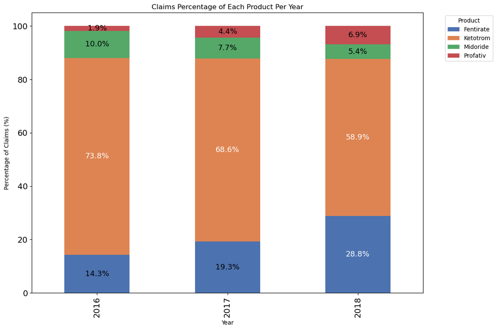

```python
import pandas as pd
import matplotlib.pyplot as plt

# Map product codes to names
code_map = {"J1885": "Ketotrom", "J2250": "Midoride", "J3010": "Fentirate", "J2704": "Profativ"}
colors = {"Fentirate": '#4C72B0', "Ketotrom": '#DD8452', "Midoride": '#55A868', "Profativ": '#C44E52'}

# Prepare data
main_data['product_name'] = main_data['product_code'].map(code_map)
main_data['Year'] = pd.to_datetime(main_data['claim_date']).dt.year
df = main_data[main_data['Year'].isin([2016, 2017, 2018])]

# Group and calculate percentages
grouped = df.groupby(['Year', 'product_name']).size().unstack(fill_value=0)
percentages = grouped.div(grouped.sum(axis=1), axis=0) * 100

# Plot
ax = percentages.plot(kind='bar', stacked=True, figsize=(12, 8), color=[colors[col] for col in percentages.columns])
ax.set(title='Claims Percentage of Each Product Per Year', xlabel='Year', ylabel='Percentage of Claims (%)')
ax.set_ylim(0, 105)
ax.legend(title='Product', bbox_to_anchor=(1.05, 1), loc='upper left')
ax.tick_params(labelsize=14)

# Add labels
for i, year in enumerate(percentages.index):
    y = 0
    for product in percentages.columns:
        pct = percentages.loc[year, product]
        if pct > 0.3:
            ax.text(i, y + pct / 2, f'{pct:.1f}%', ha='center', va='center',
                    fontsize=13, color='white' if pct > 20 else 'black')
        y += pct

plt.tight_layout()
plt.show()
```

```python
data_filtered['claim_date']
```

```
0       2016-09-26
1       2017-12-13
2       2017-05-19
3       2017-04-03
4       2018-11-03
           ...
28363   2018-07-11
28364   2016-04-08
28365   2018-06-30
28366   2018-10-30
28367   2018-10-08
Name: claim_date, Length: 28351, dtype: datetime64[ns]
```

## 2] A 100% stacked bar graph showing the number of patients of each product per year, where one bar represents one year.

```python
# Pivot table: unique patients per product by year
unique_patients_df = data_filtered.pivot_table(
    index=data_filtered['claim_date'].dt.year,
    columns='product_name',
    values='Patient_id',
    aggfunc=pd.Series.nunique,
    fill_value=0
)

# Show the result
unique_patients_df
```

| product_name claim_date | Fentirate | Ketotrom | Midoride | Profativ |
| --- | --- | --- | --- | --- |
| 2016 | 544 | 2017 | 395 | 81 |
| 2017 | 862 | 2155 | 398 | 229 |
| 2018 | 1266 | 2021 | 283 | 367 |

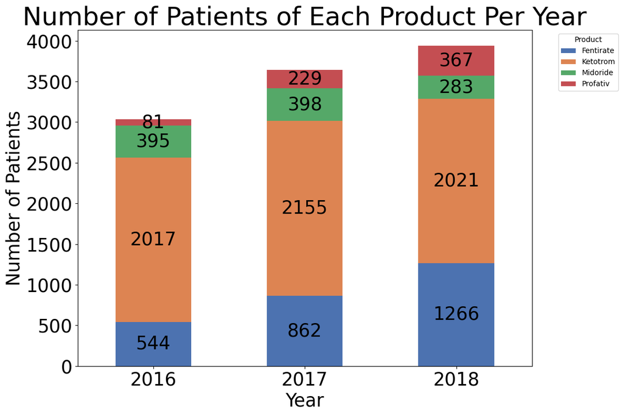

```python
import matplotlib.pyplot as plt

# Mapping product codes to product names
product_code_to_name = {
    "J1885": "Ketotrom",
    "J2250": "Midoride",
    "J3010": "Fentirate",
    "J2704": "Profativ"
}
main_data['product_name'] = main_data['product_code'].map(product_code_to_name)

# Custom colors for consistency
colors = {
    'Fentirate': '#4C72B0',
    'Ketotrom': '#DD8452',
    'Midoride': '#55A868',
    'Profativ': '#C44E52'
}

# Group data by year and product name, then count the number of unique patients
patients_per_year_product = data_filtered.groupby(
    [data_filtered['claim_date'].dt.year, 'product_name']
)['Patient_id'].nunique().unstack(fill_value=0)

# Plotting the stacked bar graph with custom colors
plt.figure(figsize=(12, 8))
ax = patients_per_year_product.plot(
    kind='bar',
    stacked=True,
    ax=plt.gca(),
    color=[colors[col] for col in patients_per_year_product.columns]
)

plt.title('Number of Patients of Each Product Per Year', fontsize=35)
plt.xlabel('Year', fontsize=25)
plt.ylabel('Number of Patients', fontsize=25)
plt.xticks(rotation=0, fontsize=25)
plt.yticks(fontsize=25)
plt.legend(title='Product', bbox_to_anchor=(1.05, 1), loc='upper left')

# Annotate numbers on bars
for bar in ax.containers:
    ax.bar_label(bar, label_type='center', fontsize=25)

plt.tight_layout()
plt.show()
```

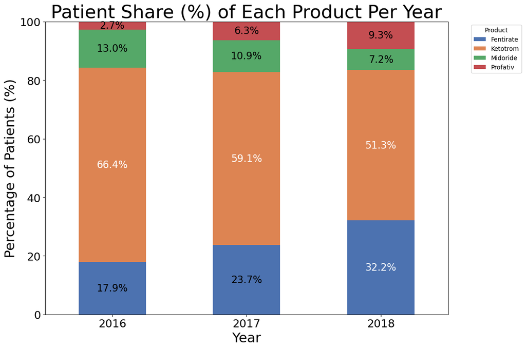

```python
import matplotlib.pyplot as plt

# Mapping product codes to product names
product_code_to_name = {
    "J1885": "Ketotrom",
    "J2250": "Midoride",
    "J3010": "Fentirate",
    "J2704": "Profativ"
}
main_data['product_name'] = main_data['product_code'].map(product_code_to_name)

# Custom product colors
colors = {
    'Fentirate': '#4C72B0',
    'Ketotrom': '#DD8452',
    'Midoride': '#55A868',
    'Profativ': '#C44E52'
}

# Group data by year and product name, then count unique patients
patients_per_year_product = data_filtered.groupby(
    [data_filtered['claim_date'].dt.year, 'product_name']
)['Patient_id'].nunique().unstack(fill_value=0)

# Convert to percentage share per year
patients_percent = patients_per_year_product.div(patients_per_year_product.sum(axis=1), axis=0) * 100

# Plotting the 100% stacked bar chart
plt.figure(figsize=(12, 8))
ax = patients_percent.plot(
    kind='bar',
    stacked=True,
    ax=plt.gca(),
    color=[colors[product] for product in patients_percent.columns]
)

# Titles and labels
plt.title('Patient Share (%) of Each Product Per Year', fontsize=30)
plt.xlabel('Year', fontsize=22)
plt.ylabel('Percentage of Patients (%)', fontsize=22)
plt.xticks(rotation=0, fontsize=18)
plt.yticks(fontsize=18)
plt.ylim(0, 100)
plt.legend(title='Product', bbox_to_anchor=(1.05, 1), loc='upper left')

# Add percentage labels inside each stack
for year_idx, year in enumerate(patients_percent.index):
    y_offset = 0
    for product in patients_percent.columns:
        height = patients_percent.loc[year, product]
        if height > 2:  # Only label segments with visible size
            label_y = y_offset + height / 2
            ax.text(
                x=year_idx,
                y=label_y,
                s=f'{height:.1f}%',
                ha='center',
                va='center',
                fontsize=16,
                color='white' if height > 25 else 'black'
            )
        y_offset += height

plt.tight_layout()
plt.show()
```

## Obervation:

We can see that the number of patients using Product 3 (Fentirate) has consistently gained more patients each year.This shows it’s becoming more trusted and preferred by both doctors and patients. On the other hand, Product 1 (Ketotrom) and Product 2 (Midoride) have seen little to no growth. This suggests that Fentirate is becoming more popular — maybe even taking patients away from the other two products. This is a clear sign that Ketotrom and Midoride need a stronger push to stay competitive. If this trend continues, Products 1 and 2 could lose even more ground, so it’s important to take action now.

## Recommendation:

To turn things around, the company should launch a focused marketing campaign for Midoride. The goal should be to clearly show why Midoride is a better or smarter choice compared to Fentirate. This could include benefits like faster recovery, fewer side effects, or better longterm outcomes. The campaign should use simple, clear messages supported by real-world data and patient success stories. It should target doctors, especially in areas where Fentirate has gained the most traction. At the same time, educating healthcare providers on when and why to choose Midoride could help rebuild trust and interest. The key is to remind the market what makes Midoride valuable and back it up with strong evidence.

## 3] A 100% stacked bar graph showing the number of HCPs (I.e., writers) writing claims for each product per year, where one bar represents one year

```python
# Pivot table: number of unique HCPs writing claims by year and product
unique_hcps_df = data_filtered.pivot_table(
    index=data_filtered['claim_date'].dt.year,
    columns='product_name',
    values='npi_id',
    aggfunc=pd.Series.nunique,
    fill_value=0
)

# Show the pivot table
unique_hcps_df
```

| product_name claim_date | Fentirate | Ketotrom | Midoride | Profativ |
| --- | --- | --- | --- | --- |
| 2016 | 344 | 492 | 285 | 72 |
| 2017 | 416 | 495 | 276 | 187 |
| 2018 | 468 | 496 | 226 | 268 |

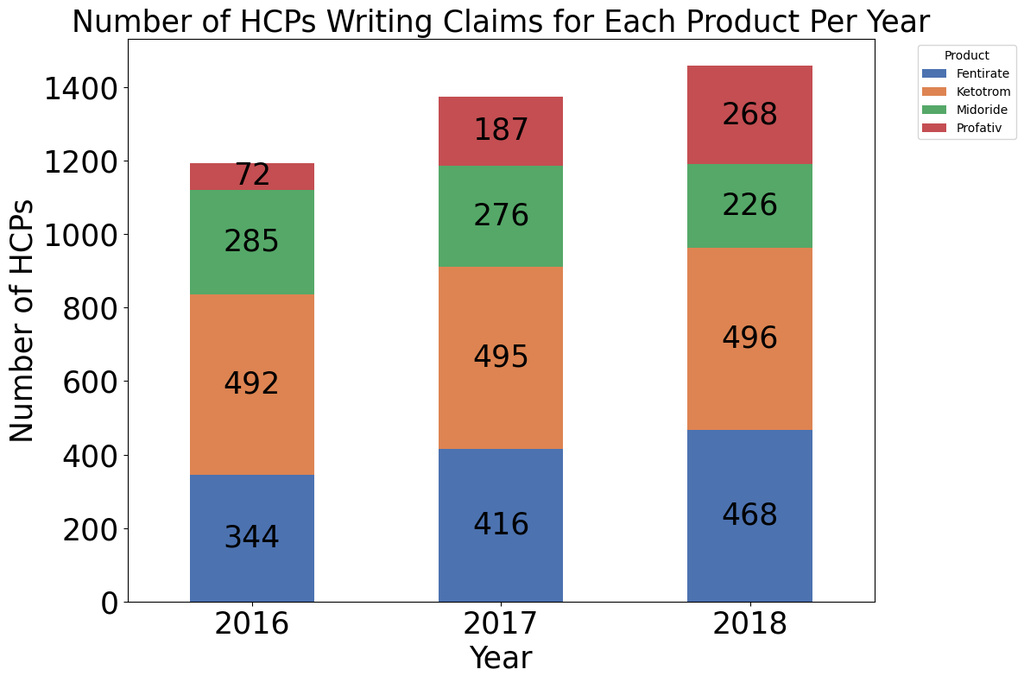

```python
import matplotlib.pyplot as plt

# Mapping product codes to product names
product_code_to_name = {
    "J1885": "Ketotrom",
    "J2250": "Midoride",
    "J3010": "Fentirate",
    "J2704": "Profativ"
}
main_data['product_name'] = main_data['product_code'].map(product_code_to_name)

# Define consistent product colors
colors = {
    'Fentirate': '#4C72B0',
    'Ketotrom': '#DD8452',
    'Midoride': '#55A868',
    'Profativ': '#C44E52'
}

# Group data by year and product name, then count the number of unique HCPs (writers)
hcp_per_year_product = data_filtered.groupby(
    [data_filtered['claim_date'].dt.year, 'product_name']
)['npi_id'].nunique().unstack(fill_value=0)

# Plotting the stacked bar graph with color
plt.figure(figsize=(12, 8))
ax = hcp_per_year_product.plot(
    kind='bar',
    stacked=True,
    ax=plt.gca(),
    color=[colors[col] for col in hcp_per_year_product.columns]
)

plt.title('Number of HCPs Writing Claims for Each Product Per Year', fontsize=25)
plt.xlabel('Year', fontsize=25)
plt.ylabel('Number of HCPs', fontsize=25)
plt.xticks(rotation=0, fontsize=25)
plt.yticks(fontsize=25)
plt.legend(title='Product', bbox_to_anchor=(1.05, 1), loc='upper left')

# Annotate numbers on bars
for bar in ax.containers:
    ax.bar_label(bar, label_type='center', fontsize=25)

plt.tight_layout()
plt.show()
```

## 4]. What do you observe from the charts above? What would be your actionable recommendations based on your observations?

**Observations:**

This trend suggests that Fentirate is not only connecting with patients, but also gaining the trust of HCPs — possibly due to perceived benefits like better outcomes, easier use, or stronger marketing. For the company behind Ketotrom and Midoride, this highlights the need to take action and find ways to re-engage prescribers and make a stronger case for Midoride.

**Recommendations:**

**Launch an HCP-Focused Education and Engagement Program for Midoride**

To regain momentum and improve adoption, it’s essential to connect more directly with healthcare providers and highlight what makes Midoride a strong choice. The goal should be to boost awareness, reinforce its value, and address any gaps in understanding that might be affecting prescribing decisions.

Key parts of this program should include:

- Clear, evidence-based materials: Share clinical trial results, patient success stories, and real-world data that demonstrate Midoride’s safety and effectiveness in practice.
- Two way communication: Create opportunities for HCPs to share their experiences and concerns. This feedback can help refine the messaging and uncover potential barriers to adoption.
- Ongoing support: Consider follow-ups, Q&A sessions, or digital resources that make it easy for HCPs to stay informed and confident in prescribing Midoride.

## B]. Calculate and analyze the number of claims per HCP (aka writer) and the number of patients per HCP for each product

## 1]. A line graph showing the number of claims per writer per year, where one line represents one product, and one set of vertical data points are for one year.

**Determine the average number of claims submitted and patients seen by each HCP for each product.**

```python
# Extract claim year from the date
data_filtered.loc[:, 'year'] = data_filtered['claim_date'].dt.year

# Calculate average number of claims per HCP for each product per year
claims_per_hcp = (
    data_filtered.groupby(['product_name', 'year'])['claim_id'].count() /
    data_filtered.groupby(['product_name', 'year'])['npi_id'].nunique()
)

# Unstack for plotting
claims_per_hcp_unstacked = claims_per_hcp.unstack(level=0)[['Ketotrom', 'Midoride', 'Fentirate', 'Profativ']]

# Display the result
claims_per_hcp_unstacked
```

| product_name year | Ketotrom | Midoride | Fentirate | Profativ |
| --- | --- | --- | --- | --- |
| 2016 | 6.408537 | 1.505263 | 1.770349 | 1.125000 |
| 2017 | 7.464646 | 1.510870 | 2.502404 | 1.267380 |
| 2018 | 6.651210 | 1.336283 | 3.446581 | 1.440299 |

```python
# Extract claim year from claim_date
data_filtered.loc[:, 'year'] = data_filtered['claim_date'].dt.year

# Calculate average number of patients per HCP for each product per year
patients_per_hcp = (
    data_filtered.groupby(['product_name', 'year'])['Patient_id'].nunique() /
    data_filtered.groupby(['product_name', 'year'])['npi_id'].nunique()
)

# Unstack for easier viewing or plotting
patients_per_hcp_unstacked = patients_per_hcp.unstack(level=0)[['Ketotrom', 'Midoride', 'Fentirate', 'Profativ']]

# Display the result
patients_per_hcp_unstacked
```

| product_name year | Ketotrom | Midoride | Fentirate | Profativ |
| --- | --- | --- | --- | --- |
| 2016 | 4.099593 | 1.385965 | 1.581395 | 1.125000 |
| 2017 | 4.353535 | 1.442029 | 2.072115 | 1.224599 |
| 2018 | 4.074597 | 1.252212 | 2.705128 | 1.369403 |

[figure not shown]

```python
import pandas as pd
import matplotlib.pyplot as plt

# Define consistent colors for each product
colors = {
    'Fentirate': '#4C72B0',
    'Ketotrom': '#DD8452',
    'Midoride': '#55A868',
    'Profativ': '#C44E52'
}

# Group data by year, product name, and HCP, then count the number of claims
claims_per_hcp = data_filtered.groupby(
    [data_filtered['claim_date'].dt.year, 'product_name', 'npi_id']
)['claim_id'].count().reset_index(name='total_claims')

# Sum the number of claims per HCP for each product per year
total_claims_per_hcp = claims_per_hcp.groupby(
    ['claim_date', 'product_name']
).agg({'total_claims': 'sum'}).reset_index()

# Pivot for plotting
total_claims_pivot = total_claims_per_hcp.pivot(
    index='claim_date', columns='product_name', values='total_claims'
)

# Plotting the line graph with custom colors
plt.figure(figsize=(12, 8))
for product in total_claims_pivot.columns:
    plt.plot(
        total_claims_pivot.index,
        total_claims_pivot[product],
        marker='o',
        label=product,
        color=colors.get(product)
    )

plt.title('Total Number of Claims Per Writer Per Year', fontsize=25)
plt.xlabel('Year', fontsize=25)
plt.ylabel('Total Claims per HCP', fontsize=25)
plt.xticks([2016, 2017, 2018], ['2016', '2017', '2018'], fontsize=20)
plt.yticks(fontsize=20)
plt.legend(title='Product', bbox_to_anchor=(1.05, 1), loc='upper left')
plt.grid(True)
plt.tight_layout()
plt.show()
```

## 2]. A line graph showing the number of patients per writer per year, where one line represents one product, and one set of vertical data points are for one year.

[figure not shown]

```python
import matplotlib.pyplot as plt

# Group and reshape the data
pivot = data_filtered.groupby([
    data_filtered['claim_date'].dt.year,
    'product_name', 'npi_id'
])['Patient_id'].nunique().reset_index().groupby(
    ['claim_date', 'product_name']
)['Patient_id'].sum().unstack()

# Plot
plt.figure(figsize=(12, 8))
for product in pivot.columns:
    plt.plot(pivot.index, pivot[product], marker='o', label=product, color=colors.get(product))

plt.title('Total Number of Patients per HCP per Year', fontsize=25)
plt.xlabel('Year', fontsize=25)
plt.ylabel('Total Patients per HCP', fontsize=25)
plt.xticks([2016, 2017, 2018], fontsize=20)
plt.yticks(fontsize=20)
plt.legend(title='Product', bbox_to_anchor=(1.05, 1), loc='upper left')
plt.grid(True)
plt.tight_layout()
plt.show()
```

# 3. What do you observe from the charts above? What would be your actionable recommendations based on your observations?

**Recommendations:**

To improve Midoride’s performance, the company should:

- Establish a feedback loop with HCPs currently prescribing Midoride to better understand their experiences and pain points.
- Develop support tools and training programs that help HCPs manage more patients effectively with Midoride.
- Incentivize adoption through performance bonuses, patient outcome tracking, or continuing education credits.
- Highlight clinical benefits and differentiators of Midoride in marketing materials, especially targeting regions and specialties with declining use.

## C]. Find the top 5 territories with the most drop in claims volume from year 2017 to 2018 for the variant brand and compare it with that of the competitor brand (Product 3 – J3010).

### i. Find the territory-level claims volume per product per year.

```python
# Get the total number of unique claims for Product J2250 (Midoride) per territory in 2016–2018
variant_brand_claims = main_data[
    (main_data['product_code'] == 'J2250') &
    (pd.to_datetime(main_data['claim_date']).dt.year.isin([2016, 2017, 2018]))
]

# Display the filtered DataFrame
variant_brand_claims.head()
```

|  | claim_id | Patient_id | npi_id | claim_date | diagnosis_code | product_code | Patient Age | Gender | Address | City | State | Zip Code | HCP Speciality | Territory Name | Region Name | diagnosis_code_initials | Diagnosis code Speciality | product_name | Year |
| --- | --- | --- | --- | --- | --- | --- | --- | --- | --- | --- | --- | --- | --- | --- | --- | --- | --- | --- | --- |
| 1195 | 100020 | 1112 | 9.710007e+09 | 2017-11-11 | H40003 | J2250 | 20 | Female | 988 Jones Crest | North Ryan | GU | 13360 | Neurology | Atlanta, GA | Southeast | H | Eye and Adnexa, Ear and Mastoid Process | Midoride | 2017 |
| 1562 | 100020 | 13053 | 8.968071e+09 | 2017-03-30 | R51 | J2250 | 67 | Female | 1047 Shah Courts | Bobbyhaven | LA | 06830 | Anesthesiology | St Louis, MO | Midwest | R | Symptoms, Signs and Abnormal Clinical and Lab ... | Midoride | 2017 |
| 2238 | 103227 | 12999 | 5.455026e+09 | 2016-10-25 | I10 | J2250 | 37 | Male | 2805 Hill Summit | East Shane | GA | 29075 | Anesthesiology | Houston, TX | Southeast | I | Circulatory System | Midoride | 2016 |
| 2244 | 104117 | 10836 | 2.893930e+09 | 2017-12-09 | M1611 | J2250 | 60 | Female | 073 Kimberly Rapid | Angelburgh | IL | 08837 | Anesthesiology | St Louis, MO | Midwest | M | Musculoskeletal and Connective Tissue | Midoride | 2017 |
| 2248 | 104683 | 10297 | 5.434716e+09 | 2017-03-02 | I10 | J2250 | 65 | Female | 78668 Ryan Mountain | Maryberg | TN | 96861 | Gastroenterology | Cincinnati, OH | Midwest | I | Circulatory System | Midoride | 2017 |

```python
# Territory-level claims volume for Product J2250 (Midoride) per year:

# Filter for Midoride (J2250) and years 2016-2018
variant_brand_claims = main_data[
    (main_data['product_code'] == 'J2250') &
    (pd.to_datetime(main_data['claim_date']).dt.year.isin([2016, 2017, 2018]))
].copy()

# Add Claim_year column
variant_brand_claims['Claim_year'] = pd.to_datetime(variant_brand_claims['claim_date']).dt.year

# Pivot to get territory-level claim counts per year
variant_brand_territory_level = variant_brand_claims.pivot_table(
    index='Claim_year',
    columns='Territory Name',
    aggfunc='size',
    fill_value=0
)

# Transpose so each row is a territory
variant_brand_territory_level = variant_brand_territory_level.transpose()

# Display result
variant_brand_territory_level
```

| Claim_year Territory Name | 2016 | 2017 | 2018 |
| --- | --- | --- | --- |
| Albany, NY | 14 | 20 | 19 |
| Atlanta, GA | 19 | 24 | 17 |
| Birmingham, AL | 4 | 8 | 5 |
| Boston, MA | 33 | 34 | 25 |
| Charlotte, NC | 8 | 5 | 6 |
| Chicago, IL | 13 | 9 | 10 |
| Cincinnati, OH | 9 | 11 | 10 |
| Dallas, TX | 28 | 20 | 13 |
| Denver, CO | 20 | 14 | 12 |
| Detroit, MI | 12 | 5 | 6 |
| Houston, TX | 22 | 14 | 16 |
| LA-San Diego, CA | 29 | 38 | 16 |
| Minneapolis, MN | 15 | 15 | 7 |
| New York, NY | 24 | 40 | 17 |
| Orlando, FL | 27 | 31 | 26 |
| Philedelphia, PA | 30 | 27 | 18 |
| Phoenix, AZ | 11 | 10 | 3 |
| Pittsburg, PA | 15 | 10 | 13 |
| San Jose, CA | 22 | 21 | 23 |
| Seattle, WA | 17 | 16 | 13 |
| St Louis, MO | 19 | 22 | 6 |
| Washington, D.C. | 38 | 23 | 21 |

```python
# calculate year-over-year (YoY) change (%) in claims volume for Midoride (J2250) between 2017 and 2018 by territory:

# Filter for Midoride (J2250) and add year column
variant_brand_claims = main_data[
    (main_data['product_code'] == 'J2250') &
    (pd.to_datetime(main_data['claim_date']).dt.year.isin([2016, 2017, 2018]))
].copy()
variant_brand_claims['Claim_year'] = pd.to_datetime(variant_brand_claims['claim_date']).dt.year

# Create pivot table: rows = Territory, columns = Year, values = claim counts
variant_brand_territory_level = variant_brand_claims.pivot_table(
    index='Claim_year',
    columns='Territory Name',
    aggfunc='size',
    fill_value=0
).transpose()

# Calculate YoY % change from 2017 to 2018
variant_brand_territory_level['yoy_change'] = (
    (variant_brand_territory_level[2018] - variant_brand_territory_level[2017]) /
     variant_brand_territory_level[2017]
) * 100

# Display result
variant_brand_territory_level
```

| Claim_year Territory Name | 2016 | 2017 | 2018 | yoy_change |
| --- | --- | --- | --- | --- |
| Albany, NY | 14 | 20 | 19 | -5.000000 |
| Atlanta, GA | 19 | 24 | 17 | -29.166667 |
| Birmingham, AL | 4 | 8 | 5 | -37.500000 |
| Boston, MA | 33 | 34 | 25 | -26.470588 |
| Charlotte, NC | 8 | 5 | 6 | 20.000000 |
| Chicago, IL | 13 | 9 | 10 | 11.111111 |
| Cincinnati, OH | 9 | 11 | 10 | -9.090909 |
| Dallas, TX | 28 | 20 | 13 | -35.000000 |
| Denver, CO | 20 | 14 | 12 | -14.285714 |
| Detroit, MI | 12 | 5 | 6 | 20.000000 |
| Houston, TX | 22 | 14 | 16 | 14.285714 |
| LA-San Diego, CA | 29 | 38 | 16 | -57.894737 |
| Minneapolis, MN | 15 | 15 | 7 | -53.333333 |
| New York, NY | 24 | 40 | 17 | -57.500000 |
| Orlando, FL | 27 | 31 | 26 | -16.129032 |
| Philedelphia, PA | 30 | 27 | 18 | -33.333333 |
| Phoenix, AZ | 11 | 10 | 3 | -70.000000 |
| Pittsburg, PA | 15 | 10 | 13 | 30.000000 |
| San Jose, CA | 22 | 21 | 23 | 9.523810 |
| Seattle, WA | 17 | 16 | 13 | -18.750000 |
| St Louis, MO | 19 | 22 | 6 | -72.727273 |
| Washington, D.C. | 38 | 23 | 21 | -8.695652 |

```python
# sort the territories by year-over-year % change from smallest to largest

# Sort the territories from smallest to largest yoy_change
variant_brand_territory_level_sorted = variant_brand_territory_level.sort_values(by='yoy_change')

# Display the sorted DataFrame
variant_brand_territory_level_sorted
```

| Claim_year Territory Name | 2016 | 2017 | 2018 | yoy_change |
| --- | --- | --- | --- | --- |
| St Louis, MO | 19 | 22 | 6 | -72.727273 |
| Phoenix, AZ | 11 | 10 | 3 | -70.000000 |
| LA-San Diego, CA | 29 | 38 | 16 | -57.894737 |
| New York, NY | 24 | 40 | 17 | -57.500000 |
| Minneapolis, MN | 15 | 15 | 7 | -53.333333 |
| Birmingham, AL | 4 | 8 | 5 | -37.500000 |
| Dallas, TX | 28 | 20 | 13 | -35.000000 |
| Philedelphia, PA | 30 | 27 | 18 | -33.333333 |
| Atlanta, GA | 19 | 24 | 17 | -29.166667 |
| Boston, MA | 33 | 34 | 25 | -26.470588 |
| Seattle, WA | 17 | 16 | 13 | -18.750000 |
| Orlando, FL | 27 | 31 | 26 | -16.129032 |
| Denver, CO | 20 | 14 | 12 | -14.285714 |
| Cincinnati, OH | 9 | 11 | 10 | -9.090909 |
| Washington, D.C. | 38 | 23 | 21 | -8.695652 |
| Albany, NY | 14 | 20 | 19 | -5.000000 |
| San Jose, CA | 22 | 21 | 23 | 9.523810 |
| Chicago, IL | 13 | 9 | 10 | 11.111111 |
| Houston, TX | 22 | 14 | 16 | 14.285714 |
| Charlotte, NC | 8 | 5 | 6 | 20.000000 |
| Detroit, MI | 12 | 5 | 6 | 20.000000 |
| Pittsburg, PA | 15 | 10 | 13 | 30.000000 |

**i. Find the territory-level claims for the competitor product (J3010)**

```python
# Get the total number of unique claims for the competitor Product (J3010) per territory in 2016 - 2018
competitor_brand_claims = main_data[main_data['product_code'] == 'J3010']
competitor_brand_claims = competitor_brand_claims[competitor_brand_claims['claim_date'].dt.year.isin([2016, 2017, 2018])]
competitor_brand_claims.head()
```

|  | claim_id | Patient_id | npi_id | claim_date | diagnosis_code | product_code | Patient Age | Gender | Address | City | State | Zip Code | HCP Speciality | Territory Name | Region Name | diagnosis_code_initials | Diagnosis code Speciality | product_name | Year |
| --- | --- | --- | --- | --- | --- | --- | --- | --- | --- | --- | --- | --- | --- | --- | --- | --- | --- | --- | --- |
| 34 | 100020 | 10364 | 1.304896e+09 | 2016-12-27 | I10 | J3010 | 78 | Male | 166 Hopkins Passage | Allentown | CA | 61466 | Anesthesiology | New York, NY | Northeast | I | Circulatory System | Fentirate | 2016 |
| 431 | 100020 | 12645 | 2.711836e+09 | 2017-01-16 | I10 | J3010 | 46 | Male | 9853 Frey Ports | Clarkport | RI | 27115 | Cardiology | Houston, TX | Southeast | I | Circulatory System | Fentirate | 2017 |
| 1728 | 100020 | 10581 | 6.243635e+09 | 2017-01-01 | I10 | J3010 | 76 | Male | 4507 Powell Inlet | Edwardmouth | GA | 38317 | Cardiology | Orlando, FL | Southeast | I | Circulatory System | Fentirate | 2017 |
| 2229 | 101610 | 12587 | 3.776911e+09 | 2016-12-06 | H9190 | J3010 | 46 | Male | 994 Kathryn Walks | West Carla | OR | 31220 | Anesthesiology | Albany, NY | Northeast | H | Eye and Adnexa, Ear and Mastoid Process | Fentirate | 2016 |
| 2242 | 103785 | 12204 | 1.578715e+09 | 2017-11-28 | M25551 | J3010 | 28 | Male | 2040 Sara Unions Apt. 924 | Richardsfurt | FM | 10596 | Neurology | St Louis, MO | Midwest | M | Musculoskeletal and Connective Tissue | Fentirate | 2017 |

```python
# Filter for competitor product J3010 (Fentirate) and years 2016-2018
competitor_brand_claims = main_data[
    (main_data['product_code'] == 'J3010') &
    (main_data['claim_date'].dt.year.isin([2016, 2017, 2018]))
]

# Extract claim year
competitor_brand_claims = competitor_brand_claims.copy()
competitor_brand_claims['Claim_year'] = competitor_brand_claims['claim_date'].dt.year

# Create pivot table: number of claims by territory and year
competitor_brand_territory_level = competitor_brand_claims.pivot_table(
    index='Claim_year',
    columns='Territory Name',
    aggfunc='size',
    fill_value=0
)

# Display the result
competitor_brand_territory_level
```

| Territory Name Claim_year | Albany, NY | Atlanta, GA | Birmingham, AL | Boston, MA | Charlotte, NC | Chicago, IL | Cincinnati, OH | Dallas, TX | Denver, CO | Detroit, MI | ... | Minneapolis, MN | New York, NY | Orlando, FL | Philedelphia, PA | Phoenix, AZ | Pittsburg, PA | San Jose, CA | Seattle, WA | St Louis, MO | Washington, D.C. |
| --- | --- | --- | --- | --- | --- | --- | --- | --- | --- | --- | --- | --- | --- | --- | --- | --- | --- | --- | --- | --- | --- |
| 2016 | 35 | 32 | 11 | 33 | 4 | 24 | 12 | 38 | 24 | 9 | ... | 14 | 33 | 40 | 43 | 7 | 25 | 38 | 39 | 23 | 35 |
| 2017 | 39 | 37 | 21 | 80 | 26 | 29 | 30 | 48 | 52 | 20 | ... | 37 | 81 | 71 | 52 | 23 | 35 | 67 | 50 | 40 | 78 |
| 2018 | 68 | 81 | 21 | 116 | 35 | 52 | 46 | 77 | 84 | 42 | ... | 50 | 153 | 134 | 91 | 32 | 68 | 72 | 64 | 54 | 104 |

3 rows × 22 columns

```python
top_5_competitor_claims = competitor_brand_territory_level.loc[[2016, 2017, 2018],top_5_territories_variant_brand.index]
top_5_competitor_claims
```

[output not shown]

[output not shown]

| Territory Name Claim_year | Boston, MA | Orlando, FL | LA-San Diego, CA | Washington, D.C. | New York, NY |
| --- | --- | --- | --- | --- | --- |
| 2016 | 33 | 40 | 55 | 35 | 33 |
| 2017 | 80 | 71 | 86 | 78 | 81 |
| 2018 | 116 | 134 | 99 | 104 | 153 |

## v. Expected outputs:

1. A clustered bar chart showing the number of claims from each of these 5 territories for each year from 2016 – 2018 for the variant brand, where one bar is for one Territory within each year and the bars for one year are clustered together.
2. A clustered bar chart showing the number of claims from each of these 5 territories for each year from 2016 – 2018 for the main competitor brand (J3010), where one bar is for one Territory within each year and the bars for one year are clustered together.

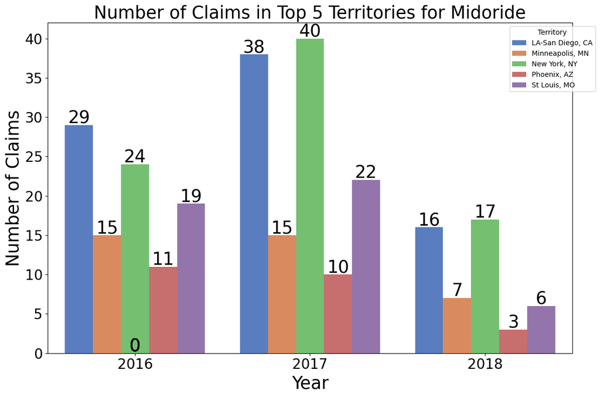

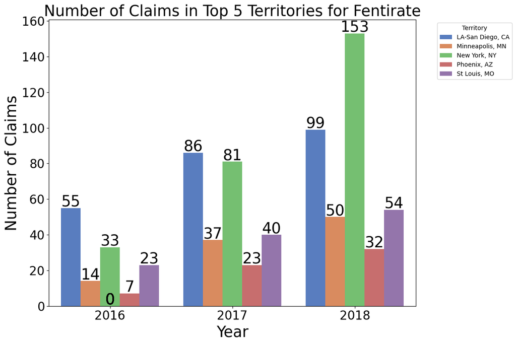

```python
import pandas as pd
import matplotlib.pyplot as plt
import seaborn as sns

# Assuming 'main_data' is your DataFrame
# Map the product codes to their names
product_code_to_name = {
    "J1885": "Ketotrom",
    "J2250": "Midoride",  # Variant brand
    "J3010": "Fentirate",  # Competitor brand
    "J2704": "Profativ"
}
main_data['product_name'] = main_data['product_code'].map(product_code_to_name)

# # Filter data for the years 2016 to 2018
# main_data['claim_date'] = pd.to_datetime(main_data['claim_date'])
# data_filtered = main_data[main_data['claim_date'].dt.year.isin([2016, 2017, 2018])]

# Find the territory-level claims volume per product per year
territory_claims = data_filtered.groupby(['Territory Name', 'product_name', data_filtered['claim_date'].dt.year])['claim_id'].count().reset_index()

# Filter for Midoride and Fentirate
territory_claims_filtered = territory_claims[territory_claims['product_name'].isin(['Midoride', 'Fentirate'])]

# Calculate the year-over-year change % for Midoride between 2017 and 2018
midoride_claims = territory_claims_filtered[territory_claims_filtered['product_name'] == 'Midoride']
midoride_pivot = midoride_claims.pivot(index='Territory Name', columns='claim_date', values='claim_id').fillna(0)
midoride_pivot['YoY_change'] = ((midoride_pivot[2018] - midoride_pivot[2017]) / midoride_pivot[2017]) * 100

# Sort territories and find top 5 with most drop
top_5_territories = midoride_pivot['YoY_change'].nsmallest(5).index

# Extract the claims count for Midoride and Fentirate for 2016-2018 in these territories
top_5_data = territory_claims_filtered[(territory_claims_filtered['Territory Name'].isin(top_5_territories)) & (territory_claims_filtered['claim_date'].isin([2016, 2017, 2018]))]

# Plotting for Midoride and Fentirate
for product in ['Midoride', 'Fentirate']:
    plt.figure(figsize=(12, 8))
    ax = sns.barplot(data=top_5_data[top_5_data['product_name'] == product], x='claim_date', y='claim_id', hue='Territory Name', errorbar=None, palette='muted', estimator=sum)

    plt.title(f'Number of Claims in Top 5 Territories for {product}', fontsize=25)
    plt.xlabel('Year', fontsize=25)
    plt.ylabel('Number of Claims', fontsize=25)
    plt.xticks(fontsize=20)
    plt.yticks(fontsize=20)
    plt.legend(title='Territory', bbox_to_anchor=(1.05, 1))

    # Annotate bar values
    for p in ax.patches:
        ax.annotate(f'{int(p.get_height())}', (p.get_x() + p.get_width() / 2., p.get_height()), ha='center', va='center', xytext=(0, 10), textcoords='offset points', fontsize=25)

    plt.tight_layout()
    plt.show()
```

## Recommendations:

1. Regain ground in high-value markets like New York and LA–San Diego by adjusting pricing slightly below Fentirate to win back prescribers.
2. In larger cities, invest in broad awareness campaigns and educational partnerships with healthcare providers.
3. For smaller markets like Phoenix or Minneapolis, focus on personalized outreach—targeted visits, local events, and direct HCP engagement.
4. Provide sales incentives in territories with the biggest Midoride drop to re-energize the field team.
5. Monitor claim trends closely over the next few months to measure the impact and adjust the approach if needed.

## 2. Identifying the trends of the Key Market Drivers of the Injectable Anesthesia Market:

#### a. Identify the medical fields or the specialties of the diagnosed patients using the diagnosis codes and the Specialties of the HCPs prescribing these drugs using the specialty group of the HCPs within the injectable anesthesia market (all 4 brands together) for years 2016-2018.

#### i. Expected outputs:

1.A pie chart showing the percentage of claims that each diagnosis specialty contributes. Extract the diagnosis code initial and map the diagnosis specialty using the diagnosis code mapping dataset. Show only the top 5 diagnosis specialties.

```python
# Get the top 5 diagnosis specialties by total number of claims
top_5_diag_specialties = (
    main_data
    .groupby(['Diagnosis code Speciality', 'diagnosis_code_initials'])['claim_id']
    .count()
    .sort_values(ascending=False)
    .head(5)
)

# Display the result
top_5_diag_specialties
```

```
Diagnosis code Speciality                                           diagnosis_code_initials
Circulatory System                                                  I                          15873
Factors Influencing Health Status and Contact with Health Services  Z                           2811
Symptoms, Signs and Abnormal Clinical and Lab Findings              R                           2018
Musculoskeletal and Connective Tissue                               M                           1928
Endocrine, Nutritional, Metabolic                                   E                           1225
Name: claim_id, dtype: int64
```

```python
# Get total claims by diagnosis speciality
total_clm_by_diag_speciality = (
    main_data
    .groupby(['Diagnosis code Speciality', 'diagnosis_code_initials'])['claim_id']
    .count()
    .sort_values(ascending=False)
    .head(5)
)

# Calculate percentage of total claims for each specialty
# Calculate percentage
top_diagnosis_specialties_percentage = (
    total_clm_by_diag_speciality / total_clm_by_diag_speciality.sum() * 100
)

# Display result
top_diagnosis_specialties_percentage
```

```
Diagnosis code Speciality                                           diagnosis_code_initials
Circulatory System                                                  I                          66.539510
Factors Influencing Health Status and Contact with Health Services  Z                          11.783693
Symptoms, Signs and Abnormal Clinical and Lab Findings              R                           8.459442
Musculoskeletal and Connective Tissue                               M                           8.082163
Endocrine, Nutritional, Metabolic                                   E                           5.135192
Name: claim_id, dtype: float64
```

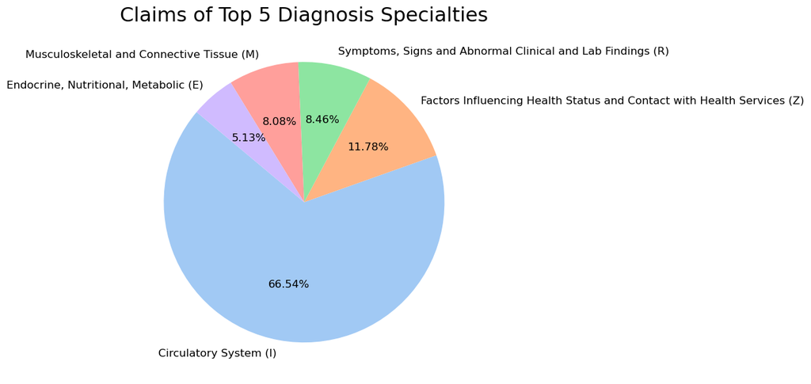

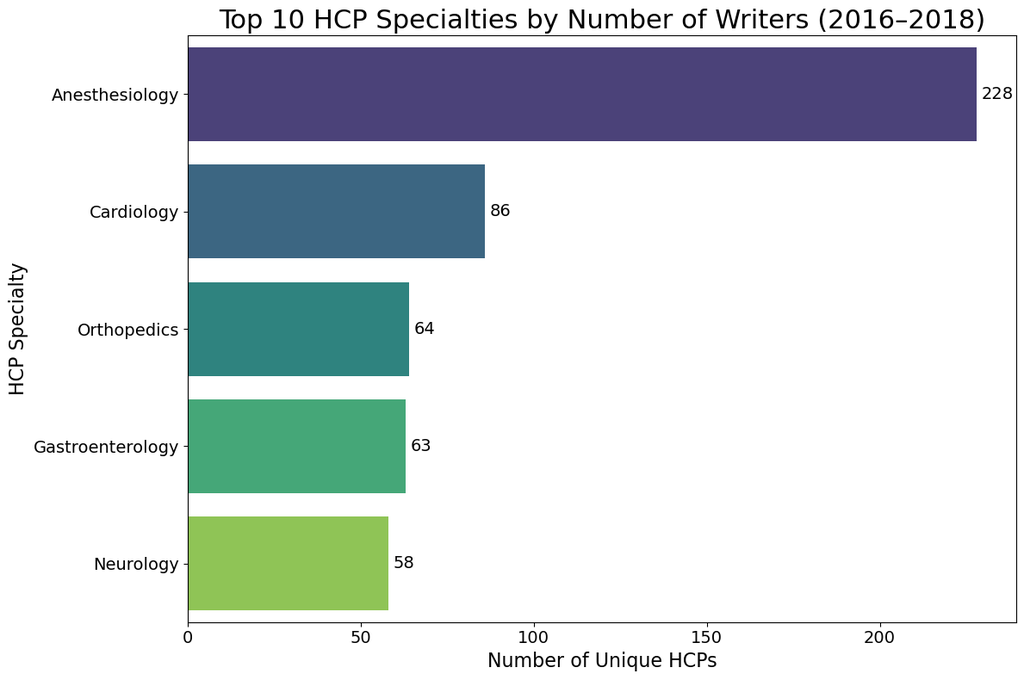

```python
import pandas as pd
import matplotlib.pyplot as plt
import seaborn as sns

# Map diagnosis code initials to specialties using what's already in main_data
# Assumes 'Diagnosis code Speciality' and 'diagnosis_code_initials' already exist in main_data
main_data['Diagnosis Specialty'] = main_data['Diagnosis code Speciality'] + ' (' + main_data['diagnosis_code_initials'] + ')'

# Filter data for years 2016–2018
main_data['claim_date'] = pd.to_datetime(main_data['claim_date'])  # ensure datetime type
data_filtered = main_data[main_data['claim_date'].dt.year.isin([2016, 2017, 2018])]

# --- PIE CHART for Top 5 Diagnosis Specialties ---
top_5_diagnosis = data_filtered.groupby('Diagnosis Specialty')['claim_id'].count().nlargest(5)

plt.figure(figsize=(10, 6))
colors = sns.color_palette("pastel")  # use a clean color palette

pie_chart = top_5_diagnosis.plot(
    kind='pie',
    autopct='%1.2f%%',
    startangle=140,
    fontsize=12,
    colors=colors
)

plt.title('Claims of Top 5 Diagnosis Specialties', fontsize=22)
plt.ylabel('')  # remove y-axis label
plt.tight_layout()
plt.show()

# --- BAR CHART for HCP Specialty Groups ---
hcp_specialty_counts = data_filtered.groupby('HCP Speciality')['npi_id'].nunique().sort_values(ascending=False).head(10)

plt.figure(figsize=(12, 8))
ax = sns.barplot(x=hcp_specialty_counts.values, y=hcp_specialty_counts.index, hue=hcp_specialty_counts.index, dodge=False, palette='viridis', legend=False)

for p in ax.patches:
    ax.annotate(
        format(p.get_width(), '.0f'),
        (p.get_width(), p.get_y() + p.get_height() / 2.),
        ha='left',
        va='center',
        xytext=(4, 0),
        textcoords='offset points',
        fontsize=14
    )

plt.title('Top 10 HCP Specialties by Number of Writers (2016–2018)', fontsize=22)
plt.xlabel('Number of Unique HCPs', fontsize=16)
plt.ylabel('HCP Specialty', fontsize=16)
plt.xticks(fontsize=14)
plt.yticks(fontsize=14)
plt.tight_layout()
plt.show()
```

#### 3. What do you observe from the charts above? What would be your actionable recommendations based on your observations?

Circulatory System related claims have the largest percentage of claims Medically critical patients prefer Injectable anesthesia

**Observations & Actionable Recommendations**

**Pie Chart Observations – Top 5 Diagnosis Specialties** • The Circulatory System dominates claim volume, accounting for over 66% of the total diagnoses. • other key areas include factors affecting health status, symptoms and abnormal lab findings, and smaller shares from musculoskeletal and endocrine/metabolic conditions. • This highlights that most patients receiving treatment are linked to cardiovascular health or systemic conditions.

**Actionable Recommendations – Diagnosis Specialties** • Focus educational outreach and clinical resources on Circulatory, Musculoskeletal, and Endocrine specialities. • Develop targeted HCP education campaigns, highlighting how Midoride supports these critical conditions. • Provide diagnostic-specific materials that emphasize clinical efficacy, safety, and cost-effectiveness of Midoride.

**Bar Chart Observations – HCP Specialty Writers** • Anesthesiologists are the top prescribers by a wide margin, followed by Cardiology and Orthopedics. • This suggests Midoride is being widely used in pain management and perioperative care, especially for invasive or high-risk patients.

**Actionable Recommendations – HCP Targeting** • Develop a Key Opinion Leader (KOL) engagement strategy focused on Anesthesiologists: • Offer early access to clinical data, real-world outcomes, and research partnerships. • Host educational seminars or webinars that demonstrate Midoride’s effectiveness in managing pain, particularly in cardiovascular patients. • Assign sales reps with cardiovascular expertise to collaborate directly with HCPs in Circulatory System–related fields. • Emphasize how Midoride can support medically complex or high-risk patients, particularly those requiring injectable anesthesia.

**Summary**

The data shows a strong alignment between Circulatory System diagnoses and high prescribing rates among Anesthesiologists. Tailored communication, education, and expert engagement can help position Midoride as the preferred treatment in these overlapping domains. This strategy is likely to expand market share while improving patient outcomes.

### 2b]. Find the trend of patient and claim distribution based on patient age within the injectable anesthesia market (all 4 brands together) for years 2016-2018.

### 1. A bar graph showing # patients from each age group using the following age buckets:

a.18-30, 31-40, 41-50, 51-60, 61-70, 71-80, 81+

```python
# Define age segments and labels
age_segments = [18, 31, 41, 51, 61, 71, 81, float('inf')]
age_buckets = ['18-30', '31-40', '41-50', '51-60', '61-70', '71-80', '81+']

# Create a new column for age categories in your main dataset
main_data['age_category'] = pd.cut(main_data['Patient Age'], bins=age_segments, labels=age_buckets, right=False)

# Count number of unique patients in each age category
patient_counts_age_group = main_data.groupby('age_category', observed=False)['Patient_id'].nunique()

# Display the result
print(patient_counts_age_group)
```

```
age_category
18-30    544
31-40    439
41-50    426
51-60    519
61-70    827
71-80    693
81+      597
Name: Patient_id, dtype: int64
```

```python
# Define age buckets
age_segments = [18, 31, 41, 51, 61, 71, 81, float('inf')]
age_buckets = ['18–30', '31–40', '41–50', '51–60', '61–70', '71–80', '81+']

# Assign age groups
main_data['age_category'] = pd.cut(main_data['Patient Age'], bins=age_segments, labels=age_buckets, right=False)

# Calculate percentage of claims by age group
claims_by_age = main_data.groupby('age_category', observed=False)['claim_id'].count()
total_claims = claims_by_age.sum()
claims_by_age_percent = (claims_by_age / total_claims) * 100

# Display result
claims_by_age_percent
```

```
age_category
18–30    13.113367
31–40    10.529470
41–50    10.057107
51–60    12.542301
61–70    21.020164
71–80    17.766497
81+      14.971094
Name: claim_id, dtype: float64
```

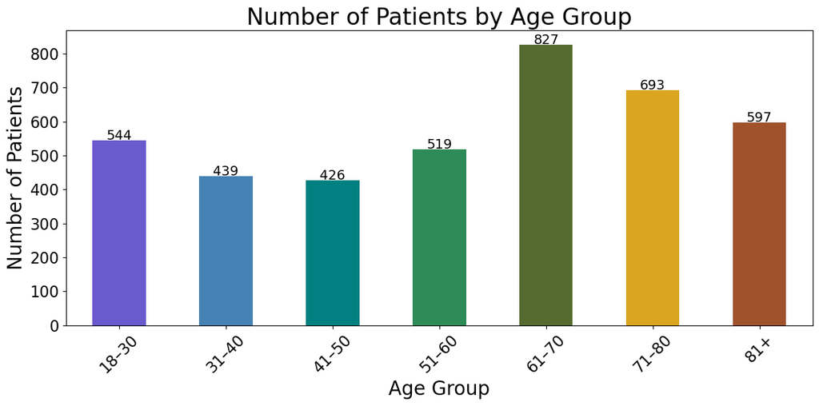

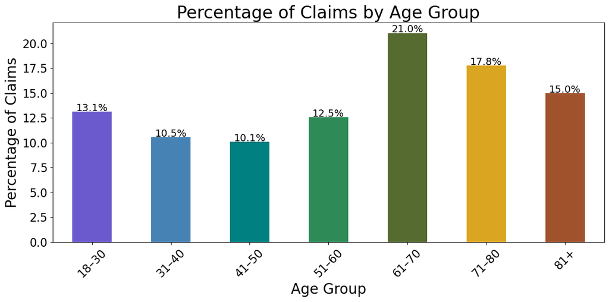

```python
import pandas as pd
import matplotlib.pyplot as plt

# --- Define age buckets and labels ---
age_buckets = [18, 31, 41, 51, 61, 71, 81, float('inf')]
age_labels = ['18–30', '31–40', '41–50', '51–60', '61–70', '71–80', '81+']

# --- Assign age group category ---
main_data['age_category'] = pd.cut(main_data['Patient Age'], bins=age_buckets, labels=age_labels, right=False)

# --- 1. Number of unique patients per age group ---
patient_age_distribution = main_data.groupby('age_category', observed=False)['Patient_id'].nunique()

# --- 2. Percentage of claims per age group ---
claim_counts = main_data.groupby('age_category', observed=False)['claim_id'].count()
claim_percentage = (claim_counts / claim_counts.sum()) * 100

# --- Subdued color palette ---
subdued_colors = ['#6A5ACD', '#4682B4', '#008080', '#2E8B57', '#556B2F', '#DAA520', '#A0522D']

# --- Plot 1: Number of Patients ---
plt.figure(figsize=(12, 6))
ax1 = patient_age_distribution.plot(kind='bar', color=subdued_colors[:len(patient_age_distribution)])
plt.title('Number of Patients by Age Group', fontsize=24)
plt.xlabel('Age Group', fontsize=20)
plt.ylabel('Number of Patients', fontsize=20)
plt.xticks(rotation=45, fontsize=16)
plt.yticks(fontsize=16)

# Add value labels
for p in ax1.patches:
    ax1.annotate(f'{int(p.get_height())}', (p.get_x() + p.get_width() / 2., p.get_height()-20),
                 ha='center', va='bottom', fontsize=14, color='black', xytext=(0, 5),
                 textcoords='offset points')

plt.tight_layout()
plt.show()

# --- Plot 2: Percentage of Claims ---
plt.figure(figsize=(12, 6))
ax2 = claim_percentage.plot(kind='bar', color=subdued_colors[:len(claim_percentage)])
plt.title('Percentage of Claims by Age Group', fontsize=24)
plt.xlabel('Age Group', fontsize=20)
plt.ylabel('Percentage of Claims', fontsize=20)
plt.xticks(rotation=45, fontsize=16)
plt.yticks(fontsize=16)

# Add value labels
for p in ax2.patches:
    ax2.annotate(f'{p.get_height():.1f}%', (p.get_x() + p.get_width() / 2., p.get_height()- 0.5),
                 ha='center', va='bottom', fontsize=14, color='black', xytext=(0, 5),
                 textcoords='offset points')

plt.tight_layout()
plt.show()
```

#### 3. What do you observe from the charts above? What would be your actionable recommendations based on your observations?

**Observations**

The charts reveal that the majority of claims are made by patients aged 60 and above. This trend suggests that older adults are the primary recipients of procedures involving anesthesia—likely due to increased healthcare needs with age, such as surgeries or chronic condition treatments. The age group 61–70 in particular stands out with the highest number of patients and claims, followed closely by those aged 71–80 and 81+. This is consistent with medical expectations, as older individuals typically undergo more invasive or complex procedures.

Interestingly, the data also highlights a notable share of claims coming from the 18–30 age group. This younger segment has a higher percentage of claims than several middle-aged groups, indicating a growing or underserved population that is also interacting with anesthesia-related care. These claims could stem from elective surgeries, dental procedures, or sports injuries—areas more common among younger adults.

**Recommendations**

Given that the majority of claims are made by patients above 60 years, educational efforts should focus on healthcare providers who routinely manage older adults—such as cardiologists, anesthesiologists, and surgical specialists. These providers should be equipped with clear, evidence-based information on the use of Midoride, particularly its benefits in elderly populations undergoing invasive procedures. For the emerging 18–30 age group, the focus should remain on engaging medical professionals who serve this demographic, such as orthopedic surgeons, dentists, and outpatient clinic staff. Awareness initiatives should prioritize formal medical channels like academic journal publications, provider-focused conferences, or clinical resource platforms like Medscape and Doximity. University-affiliated clinics and ambulatory surgery centers should also be considered as strategic outreach points. This approach ensures that prescribers are well-informed and confident in recommending Midoride to both aging and younger patient populations.

### 2c. New and continuing writer (HCP) trends of the four brands. Identify the new HCPs writing for each of the brands based on the claim year from 2016 – 2018 and identify the continuing writers for each of the brands based on the claim year for 2017 and 2018.

Expected Outputs:

##### 1.A clustered bar chart showing # new writers for each brand from each year, where one bar is for one brand, and the bars are grouped into each year from 2016 – 2018. New Writer refers to the HCPs who prescribed the brand for the first time between 2018 and 2018.

```python
main_data.head()
```

|  | claim_id | Patient_id | npi_id | claim_date | diagnosis_code | product_code | Patient Age | Gender | Address | City | ... | Zip Code | HCP Speciality | Territory Name | Region Name | diagnosis_code_initials | Diagnosis code Speciality | product_name | Year | Diagnosis Specialty | age_category |
| --- | --- | --- | --- | --- | --- | --- | --- | --- | --- | --- | --- | --- | --- | --- | --- | --- | --- | --- | --- | --- | --- |
| 0 | 100020 | 10449 | 7.829223e+09 | 2016-09-26 | I10 | 88307 | 76 | Male | 224 Teresa Mills Suite 159 | Campbellmouth | ... | 09277 | Gastroenterology | Washington, D.C. | Northeast | I | Circulatory System | NaN | 2016 | Circulatory System (I) | 71–80 |
| 1 | 100020 | 10977 | 7.360579e+09 | 2017-12-13 | I10 | Q0092 | 86 | Female | 1559 Sarah Springs Suite 587 | North Jessicaborough | ... | 63021 | Orthopedics | New York, NY | Northeast | I | Circulatory System | NaN | 2017 | Circulatory System (I) | 81+ |
| 2 | 100020 | 1109 | 1.587946e+09 | 2017-05-19 | I4891 | 86141 | 78 | Female | 8979 Mason Common Suite 166 | South Jennifershire | ... | 78837 | Orthopedics | Charlotte, NC | Southeast | I | Circulatory System | NaN | 2017 | Circulatory System (I) | 71–80 |
| 3 | 100020 | 10882 | 1.414857e+09 | 2017-04-03 | I10 | 93296 | 60 | Male | 8562 Reynolds Motorway Apt. 414 | Amandamouth | ... | 97291 | Neurology | Seattle, WA | West | I | Circulatory System | NaN | 2017 | Circulatory System (I) | 51–60 |
| 4 | 100020 | 963 | 1.414857e+09 | 2018-11-03 | I10 | 99152 | 72 | Male | 8562 Reynolds Motorway Apt. 414 | Amandamouth | ... | 97291 | Neurology | Seattle, WA | West | I | Circulatory System | NaN | 2018 | Circulatory System (I) | 71–80 |

5 rows × 21 columns

```python
filtered_df.head()
```

|  | cur_clm_uniq_id | bene_mbi_id | fac_prvdr_npi_num | clm_from_dt | clm_thru_dt | prncpl_dgns_cd | clm_pmt_amt | clm_mdcr_instnl_tot_chrg_amt | clm_line_num | clm_line_hcpcs_cd | clm_line_cvrd_pd_amt | clm_val_sqnc_num_dgns | clm_dgns_cd | clm_val_sqnc_num_prcdr | clm_prcdr_cd | clm_line_alowd_chrg_amt | clm_prvdr_spclty_cd |
| --- | --- | --- | --- | --- | --- | --- | --- | --- | --- | --- | --- | --- | --- | --- | --- | --- | --- |
| 34 | 100020 | 10364 | 1.304896e+09 | 12/27/2016 | 12/10/2016 | Z5181 | NaN | NaN | 3.0 | J3010 | 66.14 | NaN | I10 | NaN | NaN | 93.51 | 34 |
| 302 | 100020 | 12749 | 3.156424e+09 | 11/7/2016 | 1/25/2017 | Z79899 | 73.75 | 718.425135 | 3.0 | J1885 | NaN | 4.0 | I10 | NaN | NaN | NaN | NaN |
| 309 | 100020 | 10055 | 1.866101e+09 | 10/19/2017 | 1/1/2018 | H9313 | NaN | NaN | 1.0 | J1885 | 1.23 | NaN | I10 | NaN | NaN | 9.80 | 69 |
| 319 | 100020 | 12564 | 7.009227e+09 | 11/17/2016 | 9/22/2016 | E041 | 111.07 | 558.601045 | NaN | J1885 | 6.59 | 1.0 | M79602 | NaN | NaN | NaN | NaN |
| 353 | 100020 | 10181 | 9.545956e+09 | 2/23/2017 | 1/3/2017 | I10 | NaN | NaN | 4.0 | J1885 | 1.40 | NaN | I10 | NaN | NaN | 11.81 | 8 |

```python
import pandas as pd

# Ensure datetime is correct
main_data['claim_date'] = pd.to_datetime(main_data['claim_date'])

# Extract claim year
main_data['Claim_year'] = main_data['claim_date'].dt.year

# Define mapping for procedure codes to product brands
procedure_groups = {
    'J1885': 'Ketotrom',
    'J2250': 'Midoride',
    'J3010': 'Fentirate',
    'J2704': 'Profativ'
}
main_data['Product_brand'] = main_data['product_code'].map(procedure_groups)

# Find new writers: Drop duplicates so each HCP only appears once per brand
new_writers_df = main_data.drop_duplicates(subset=['npi_id', 'Product_brand'])

# Count new writers per brand per year
new_writer_counts = new_writers_df.groupby(['Claim_year', 'Product_brand'])['npi_id'].nunique().reset_index()
new_writer_counts.rename(columns={'npi_id': 'New_Writer_Count'}, inplace=True)

# Display the result
print(new_writer_counts)
```

```
    Claim_year Product_brand  New_Writer_Count
0         2016     Fentirate               102
1         2016      Ketotrom               218
2         2016      Midoride               151
3         2016      Profativ                46
4         2017     Fentirate               170
5         2017      Ketotrom               182
6         2017      Midoride               172
7         2017      Profativ               125
8         2018     Fentirate               223
9         2018      Ketotrom                99
10        2018      Midoride               107
11        2018      Profativ               193
```

```python
import pandas as pd

# Step 1: Map procedure codes to product brand names
procedure_groups = {
    'J1885': 'Ketotrom',
    'J2250': 'Midoride',
    'J3010': 'Fentirate',
    'J2704': 'Profativ'
}

# Step 2: Filter main_data for years 2016–2018 and copy
main_data['claim_date'] = pd.to_datetime(main_data['claim_date'])
joined_df_2016_2018 = main_data[main_data['claim_date'].dt.year.isin([2016, 2017, 2018])].copy()

# Step 3: Add brand and year columns
joined_df_2016_2018['Product_brand'] = joined_df_2016_2018['product_code'].map(procedure_groups)
joined_df_2016_2018['Claim_year'] = joined_df_2016_2018['claim_date'].dt.year

# Step 4: Create pivot table of new HCP writers by brand and year
new_writers = joined_df_2016_2018.drop_duplicates(subset=['npi_id', 'Product_brand']).pivot_table(
    index='Claim_year',
    columns='product_code',  # Use Procedure Code as in your screenshot
    values='npi_id',         # Counting unique HCPs
    aggfunc=pd.Series.nunique,
    fill_value=0
)[procedure_groups.keys()]  # Limit to 4 products only

# Step 5: Show result
new_writers
```

| product_code Claim_year | J1885 | J2250 | J3010 | J2704 |
| --- | --- | --- | --- | --- |
| 2016 | 218 | 151 | 102 | 46 |
| 2017 | 182 | 172 | 170 | 125 |
| 2018 | 99 | 107 | 223 | 193 |

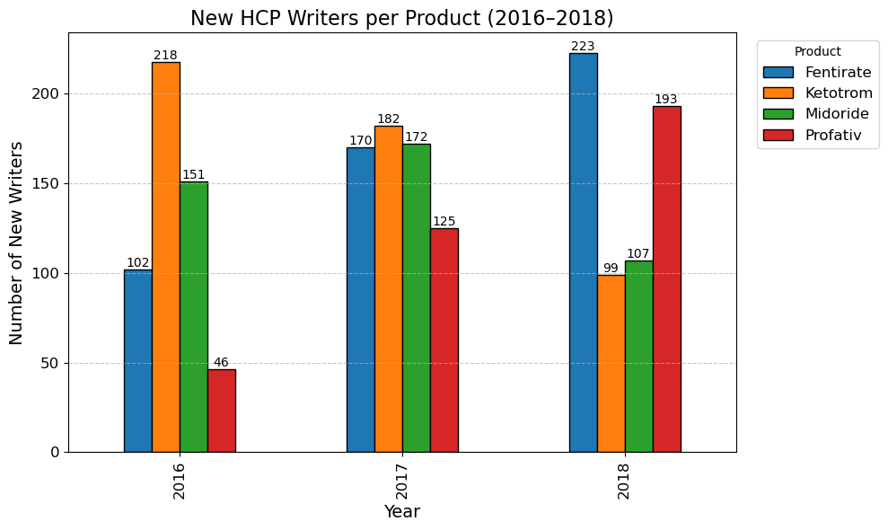

```python
import pandas as pd
import matplotlib.pyplot as plt

# Convert claim_date to datetime and extract year
main_data['Year'] = pd.to_datetime(main_data['claim_date']).dt.year

# Filter for 2016 to 2018
filtered_data = main_data[main_data['Year'].isin([2016, 2017, 2018])].copy()

# Map procedure codes to product names
product_mapping = {
    'J1885': 'Ketotrom',
    'J2250': 'Midoride',
    'J3010': 'Fentirate',
    'J2704': 'Profativ'
}
filtered_data['Product'] = filtered_data['product_code'].map(product_mapping)

# Get new writers (unique npi_id per product per year)
new_writers = (
    filtered_data
    .drop_duplicates(subset=['npi_id', 'Product'])
    .groupby(['Year', 'Product'])
    .size()
    .unstack(fill_value=0)
)

# Set consistent colors (same order: Fentirate, Ketotrom, Midoride, Profativ)
product_colors = {
    'Fentirate': '#1f77b4',  # Blue
    'Ketotrom': '#ff7f0e',   # Orange
    'Midoride': '#2ca02c',   # Green
    'Profativ': '#d62728'    # Red
}

# Plotting
ax = new_writers.plot(kind='bar', figsize=(10, 6), color=[product_colors[col] for col in new_writers.columns], edgecolor='black')

# Add numbers on bars
for p in ax.patches:
    height = p.get_height()
    if height > 0:
        ax.annotate(f'{int(height)}',
                    (p.get_x() + p.get_width() / 2, height),
                    ha='center', va='bottom', fontsize=10)

# Final touches
plt.title('New HCP Writers per Product (2016–2018)', fontsize=16)
plt.xlabel('Year', fontsize=14)
plt.ylabel('Number of New Writers', fontsize=14)
plt.xticks(fontsize=12)
plt.yticks(fontsize=12)
plt.legend(title='Product', loc='upper left', bbox_to_anchor=(1.02, 1.0), fontsize=12)
plt.tight_layout()
plt.grid(axis='y', linestyle='--', alpha=0.7)
plt.show()
```

### 2.A line chart showing # of continuing writers for each brand for each year between 2017 and 2018 where each line should belong to each brand. The continuing writers are HCPs who continued to write the brand after the first prescription in the following years.

```python
# Step 1: Define the procedure-to-brand mapping
procedure_groups = {
    'J1885': 'Ketotrom',
    'J2250': 'Midoride',
    'J3010': 'Fentirate',
    'J2704': 'Profativ'
}

# Step 2: Map using the correct column name (product_code)
joined_df_2016_2018['Product_brand'] = joined_df_2016_2018['product_code'].map(procedure_groups)

# Step 3: Display updated DataFrame
joined_df_2016_2018.head()
```

|  | claim_id | Patient_id | npi_id | claim_date | diagnosis_code | product_code | Patient Age | Gender | Address | City | ... | Region Name | diagnosis_code_initials | Diagnosis code Speciality | product_name | Year | Diagnosis Specialty | age_category | Claim_year | Product_brand | year |
| --- | --- | --- | --- | --- | --- | --- | --- | --- | --- | --- | --- | --- | --- | --- | --- | --- | --- | --- | --- | --- | --- |
| 0 | 100020 | 10449 | 7.829223e+09 | 2016-09-26 | I10 | 88307 | 76 | Male | 224 Teresa Mills Suite 159 | Campbellmouth | ... | Northeast | I | Circulatory System | NaN | 2016 | Circulatory System (I) | 71–80 | 2016 | NaN | 2016 |
| 1 | 100020 | 10977 | 7.360579e+09 | 2017-12-13 | I10 | Q0092 | 86 | Female | 1559 Sarah Springs Suite 587 | North Jessicaborough | ... | Northeast | I | Circulatory System | NaN | 2017 | Circulatory System (I) | 81+ | 2017 | NaN | 2017 |
| 2 | 100020 | 1109 | 1.587946e+09 | 2017-05-19 | I4891 | 86141 | 78 | Female | 8979 Mason Common Suite 166 | South Jennifershire | ... | Southeast | I | Circulatory System | NaN | 2017 | Circulatory System (I) | 71–80 | 2017 | NaN | 2017 |
| 3 | 100020 | 10882 | 1.414857e+09 | 2017-04-03 | I10 | 93296 | 60 | Male | 8562 Reynolds Motorway Apt. 414 | Amandamouth | ... | West | I | Circulatory System | NaN | 2017 | Circulatory System (I) | 51–60 | 2017 | NaN | 2017 |
| 4 | 100020 | 963 | 1.414857e+09 | 2018-11-03 | I10 | 99152 | 72 | Male | 8562 Reynolds Motorway Apt. 414 | Amandamouth | ... | West | I | Circulatory System | NaN | 2018 | Circulatory System (I) | 71–80 | 2018 | NaN | 2018 |

5 rows × 24 columns

```python
# Step 1: Ensure 'claim_date' is datetime and extract year
joined_df_2016_2018['Claim_year'] = pd.to_datetime(joined_df_2016_2018['claim_date']).dt.year

# Step 2: Define relevant procedure codes
procedure_groups = {
    'J1885': 'Ketotrom',
    'J2250': 'Midoride',
    'J3010': 'Fentirate',
    'J2704': 'Profativ'
}

# Step 3: Create pivot table to count unique HCPs (writers)
total_writers = joined_df_2016_2018.pivot_table(
    index='Claim_year',
    columns='product_code',  # <- use 'product_code' if it contains 'J1885', etc.
    values='npi_id',         # <- use correct HCP ID column
    aggfunc=pd.Series.nunique,
    fill_value=0
)[procedure_groups.keys()]  # limit to your 4 target procedure codes

# Step 4: Display result
total_writers
```

| product_code Claim_year | J1885 | J2250 | J3010 | J2704 |
| --- | --- | --- | --- | --- |
| 2016 | 492 | 285 | 344 | 72 |
| 2017 | 495 | 276 | 416 | 187 |
| 2018 | 496 | 226 | 468 | 268 |

```python
# Step 1: Drop duplicates to find new writers
new_writers = joined_df_2016_2018.drop_duplicates(subset=['npi_id', 'product_code']).pivot_table(
    index='Claim_year',
    columns='product_code',
    values='npi_id',
    aggfunc=pd.Series.nunique,
    fill_value=0
)[procedure_groups.keys()]

# Step 2: Calculate total writers
total_writers = joined_df_2016_2018.pivot_table(
    index='Claim_year',
    columns='product_code',
    values='npi_id',
    aggfunc=pd.Series.nunique,
    fill_value=0
)[procedure_groups.keys()]

# Step 3: Subtract to get continuing writers
continuing_writers = total_writers - new_writers

# Step 4: Display
continuing_writers
```

| product_code Claim_year | J1885 | J2250 | J3010 | J2704 |
| --- | --- | --- | --- | --- |
| 2016 | 274 | 134 | 242 | 26 |
| 2017 | 313 | 104 | 246 | 62 |
| 2018 | 397 | 119 | 245 | 75 |

```python
continuing_writers_2017_2018 = continuing_writers.loc[[2017, 2018]]
continuing_writers_2017_2018
```

| product_code Claim_year | J1885 | J2250 | J3010 | J2704 |
| --- | --- | --- | --- | --- |
| 2017 | 313 | 104 | 246 | 62 |
| 2018 | 397 | 119 | 245 | 75 |

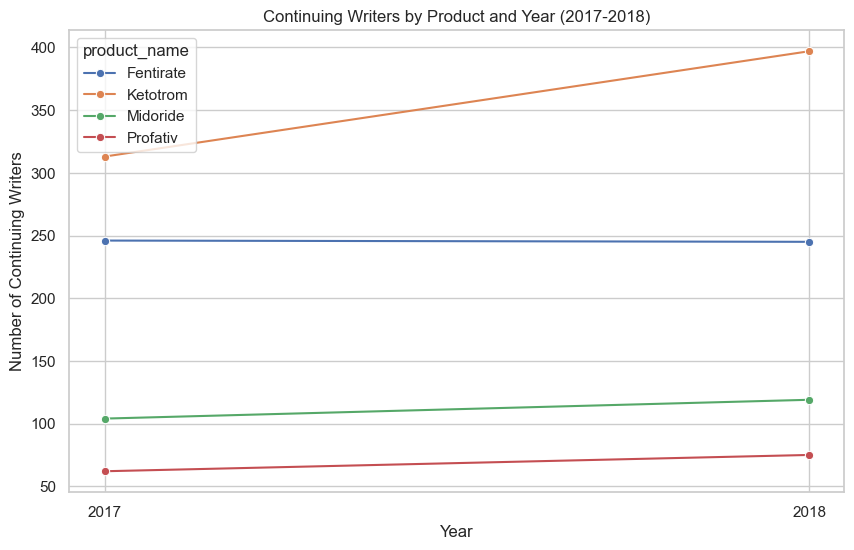

```python
import pandas as pd
import matplotlib.pyplot as plt
import seaborn as sns

# Assuming main_data is already loaded and is the DataFrame containing your data
# main_data = ...

# Convert 'claim_date' to datetime and extract the year
main_data['year'] = pd.to_datetime(main_data['claim_date']).dt.year

# Define a mapping from product codes to product names
product_names = {
    "J1885": "Ketotrom",
    "J2250": "Midoride",
    "J3010": "Fentirate",
    "J2704": "Profativ"
}

# Replace product codes with product names in the DataFrame
main_data['product_name'] = main_data['product_code'].map(product_names)

# Filter for the years 2017 and 2018
data_filtered = main_data[main_data['year'].isin([2017, 2018])]

# Mapping the new_writers data to the product names
new_writers_data = {
    "Ketotrom": {"2017": 182, "2018": 99},
    "Midoride": {"2017": 172, "2018": 107},
    "Fentirate": {"2017": 170, "2018": 223},
    "Profativ": {"2017": 125, "2018": 193}
}

# Calculate the total writers for each product and each year
total_writers = data_filtered.groupby(['product_name', 'year'])['npi_id'].nunique().reset_index()
total_writers.rename(columns={'npi_id': 'total_writers'}, inplace=True)

# Calculate the continuing writers
continuing_writers = []
for _, row in total_writers.iterrows():
    product = row['product_name']
    year = str(row['year'])
    total = row['total_writers']
    new_writers = new_writers_data.get(product, {}).get(year, 0)
    continuing = total - new_writers
    continuing_writers.append({'product_name': product, 'year': year, 'continuing_writers': continuing})

# Convert the list of dictionaries to a DataFrame
continuing_writers_df = pd.DataFrame(continuing_writers)

# Plotting
sns.set(style="whitegrid")
plt.figure(figsize=(10, 6))
sns.lineplot(data=continuing_writers_df, x='year', y='continuing_writers', hue='product_name', marker='o')
plt.title('Continuing Writers by Product and Year (2017-2018)')
plt.xlabel('Year')
plt.ylabel('Number of Continuing Writers')
plt.xticks(continuing_writers_df['year'].unique())
plt.show()
```

## 3. What do you observe from the charts above? What would be your actionable recommendations based on your observations?

**Recommendations**

To regain and grow market share, Midoride must prioritize re-engagement and retention strategies. A good starting point is to identify the HCPs who transitioned to competitor brands like Fentirate or Profativ and understand their drivers. Midoride can then initiate targeted outreach—offering comparative performance data, real-world evidence, and updated clinical findings that reinforce its therapeutic value.

Building HCP loyalty is also critical. For the existing pool of continuing prescribers, companies should aim to increase claim volume through engagement and incentives. Offering bulk purchase discounts, free samples, or exclusive training/clinical content can encourage these HCPs to write more prescriptions and remain committed to the brand.

In addition, leveraging the relative stability of Ketotrom’s performance from 2016 to 2017 provides a compelling case for a comparative messaging campaign. Positioning Midoride alongside Ketotrom with joint success metrics—especially before the 2018 drop—can help restore trust and drive re-adoption.

Lastly, it’s important to stay agile. If Fentirate’s rapid growth is tied to specific messaging, convenience, or patient outcomes, Midoride’s marketing and medical affairs teams should quickly adapt, highlight differentiators, and ensure HCPs are supported with both science and service.